# NCRB (National Crime Records Bureau) data from total IPC crimes 2001 to 2014

## by `Vaibhav Khobragade`

```python
# import all packages and set plots to be embedded inline
import numpy as np
import pandas as pd
import matplotlib.pyplot as plt
import seaborn as sb
from IPython.display import IFrame

%matplotlib inline
```

```python
documentation = IFrame(src = "https://en.wikipedia.org/wiki/National_Crime_Records_Bureau", width = 1000, height = 500)
display(documentation)
```

[interactive chart not shown]

## Preliminary Wrangling

```python
# india_crimes = pd.read_csv('india_crimes_remaster.csv')
```

```python
# pd.set_option('display.max_columns', 500)
# print(india_crimes.shape)
# india_crimes.head()
```

```
(10144, 22)
```

|  | States_or_union_territories | District | Year | Murder | Rape | Kidnapping_and_abduction_of_women_and_girls | Kidnapping_and_abduction_of_others | Dacoity | Robbery | Thefts | Riots | Criminal_breach_of_trust | Cheating | Arson | Hurt_or_grievous_hurt | Dowry_deaths | Assault_on_women_with_intent_to_outrage_her_modesty | Insult_to_modesty_of_women | Cruelty_by_husband_or_his_relatives | Importation_of_girls_from_foreign_countries | Causing_death_by_negligence | Total_ipc_crimes |
| --- | --- | --- | --- | --- | --- | --- | --- | --- | --- | --- | --- | --- | --- | --- | --- | --- | --- | --- | --- | --- | --- | --- |
| 0 | ANDHRA PRADESH | ADILABAD | 2001 | 101 | 50 | 30 | 16 | 9 | 41 | 199 | 78 | 16 | 104 | 30 | 1131 | 16 | 149 | 34 | 175 | 0 | 181 | 4154 |
| 1 | ANDHRA PRADESH | ANANTAPUR | 2001 | 151 | 23 | 30 | 23 | 8 | 16 | 366 | 168 | 11 | 65 | 69 | 1543 | 7 | 118 | 24 | 154 | 0 | 270 | 4125 |
| 2 | ANDHRA PRADESH | CHITTOOR | 2001 | 101 | 27 | 34 | 25 | 4 | 14 | 723 | 156 | 33 | 209 | 38 | 2088 | 14 | 112 | 83 | 186 | 0 | 404 | 5818 |
| 3 | ANDHRA PRADESH | CUDDAPAH | 2001 | 80 | 20 | 20 | 5 | 1 | 4 | 173 | 164 | 12 | 37 | 23 | 795 | 17 | 126 | 38 | 57 | 0 | 233 | 3140 |
| 4 | ANDHRA PRADESH | EAST GODAVARI | 2001 | 82 | 23 | 26 | 23 | 4 | 25 | 1021 | 70 | 50 | 220 | 41 | 1244 | 12 | 109 | 58 | 247 | 0 | 431 | 6507 |

```python
# india_crimes.drop('Importation_of_girls_from_foreign_countries', axis=1, inplace = True)
```

```python
# india_crimes.columns = india_crimes.columns.str.lower()
```

```python
# india_crimes.shape
```

```
(10144, 21)
```

```python
# india_crimes.district.unique()
```

```
array(['ADILABAD', 'ANANTAPUR', 'CHITTOOR', 'KADAPA', 'EAST GODAVARI',
       'GUNTUR', 'HYDERABAD', 'KARIMNAGAR', 'KHAMMAM', 'KRISHNA',
       'KURNOOL', 'MAHBUBNAGAR', 'MEDAK', 'NALGONDA', 'NELLORE',
       'NIZAMABAD', 'PRAKASAM', 'RANGA REDDY', 'SRIKAKULAM',
       'VISAKHAPATNAM', 'VIZIANAGARAM', 'WARANGAL', 'WEST GODAVARI',
       'CHANGLANG', 'DIBANG VALLEY', 'KAMENG EAST', 'KAMENG WEST',
       'LOHIT', 'PAPUM PARE', 'SIANG EAST', 'SIANG UPPER', 'SIANG WEST',
       'SUBANSIRI LOWER', 'SUBANSIRI UPPER', 'TAWANG', 'TIRAP', 'BARPETA',
       'BONGAIGAON', 'CACHAR', 'DARRANG', 'DHEMAJI', 'DHUBRI',
       'DIBRUGARH', 'ASSAM_GRP', 'GOALPARA', 'GOLAGHAT', 'KAMRUP',
       'HAILAKANDI', 'JORHAT', 'KARBI ANGLONG', 'KARIMGANJ', 'KOKRAJHAR',
       'LAKHIMPUR', 'MORIGAON', 'NORTH CACHAR HILLS', 'NAGAON', 'NALBARI',
       'ASSAM_RPO', 'SIBSAGAR', 'SONITPUR', 'TINSUKIA', 'ARARIA', 'ARWAL',
       'AURANGABAD', 'WEST CHAMPARAN', 'BANKA', 'BEGUSARAI', 'KAMIPUR',
       'BHAGALPUR', 'BHOJPUR', 'BUXAR', 'DARBHANGA', 'GAYA', 'GOPALGANJ',
       'MUNGER', 'JAMUI', 'JEHANABAD', 'KATIHAR', 'KHAGARIA',
       'KISHANGANJ', 'LAKHISARAI', 'MADHEPURA', 'MADHUBANI',
       'EAST CHAMPARAN', 'MUZAFFARPUR', 'NALANDA', 'NAWADA', 'PATNA',
       'PURNEA', 'ROHTAS', 'SAHARSA', 'SAMASTIPUR', 'SARAN', 'SHEIKHPURA',
       'SHEOHAR', 'SITAMARHI', 'SIWAN', 'SUPAUL', 'VAISHALI', 'BALRAMPUR',
       'BILASPUR', 'BIJAPUR', 'DANTEWADA', 'DHAMTARI', 'DURG', 'RAIPUR',
       'BASTAR', 'JANJGIR-CHAMPA', 'JASHPUR', 'KANKER', 'KAWARDHA',
       'KORBA', 'KORIYA', 'MAHASAMUND', 'RAIGARH', 'RAJNANDGAON',
       'SURGUJA', 'NORTH GOA', 'SOUTH GOA', 'AHMEDABAD', 'AHWA-DANG',
       'AMRELI', 'ANAND', 'BHARUCH', 'BHAVNAGAR', 'DAHOD', 'GANDHINAGAR',
       'SABARKANTHA', 'JAMNAGAR', 'JUNAGADH', 'KHEDA', 'KUTCH', 'MEHSANA',
       'NARMADA', 'NAVSARI', 'BANASKANTHA', 'PANCHMAHAL', 'PATAN',
       'PORBANDAR', 'RAJKOT', 'SURAT', 'SURENDRANAGAR', 'VADODARA',
       'VALSAD', 'AMBALA', 'BHIWANI', 'FARIDABAD', 'FATEHABAD',
       'HARYANA_GRP', 'GURGAON', 'HISAR', 'JHAJJAR', 'JIND', 'KAITHAL',
       'KARNAL', 'KURUKSHETRA', 'MAHENDRAGARH', 'PANCHKULA', 'PANIPAT',
       'REWARI', 'ROHTAK', 'SIRSA', 'SONIPAT', 'YAMUNANAGAR', 'CHAMBA',
       'HIMACHAL PRADESH_GRP', 'HAMIRPUR', 'KANGRA', 'KINNAUR', 'KULLU',
       'LAHAUL-SPITI', 'MANDI', 'SHIMLA', 'SIRMAUR', 'SOLAN', 'UNA',
       'ANANTNAG', 'PULWAMA', 'BARAMULLA', 'BORDER', 'BUDGAM', 'JAMMU',
       'SRINAGAR', 'DODA', 'GANDERBAL', 'KARGIL', 'KATHUA', 'KULGAM',
       'KUPWARA', 'LEH', 'POONCH', 'UNKNOWN', 'RAJOURI', 'RAMBAN',
       'REASI', 'UDHAMPUR', 'BOKARO', 'CHAIBASA', 'CHATRA', 'DEOGHAR',
       'DHANBAD', 'DUMKA', 'GARHWA', 'GIRIDIH', 'GODDA', 'GUMLA',
       'HAZARIBAGH', 'JAMSHEDPUR', 'JAMTARA', 'KODERMA', 'LATEHAR',
```

[output cut: 112 more lines]

```
       'KACHCHH WEST(B)', 'MAHISAGAR', 'MORBI', 'W.RLY  AHMEDABAD',
       'AMBALA (RURAL)', 'AMBALA (URBAN)', 'MAHENDERGARH',
       'IRRIGATION & POWER', 'BADDI', 'LAHAUL & SPITI', 'BENGALURU',
       'BELAGAVI', 'BALLARI', 'VIJAYAPURA', 'CHIKKABALLAPURA',
       'CHIKKAMAGALURU', 'KALABURGI', 'HUBBALLI DHARWAD', 'MANGALURU',
       'MYSURU', 'TUMAKURU', 'UTTARA KANNADA', 'DATIA', 'KHARGONE',
       'SEHORE', 'UMARIA', 'CYBER CELL', 'PALGHAR',
       'GARO HILLS SOUTH WEST', 'KHASI HILLS SOUTH WEST', 'SPL TRAFFIC',
       'MALKANGIRI', 'NABARANGPUR', 'SRP (CUTTACK)', 'SRP (ROURKELA)',
       'BATHINDA', 'SAS NAGAR', 'PRAAPGARH', 'OTHER UNITS',
       'MAHABOOB NAGAR', 'KOWAI', 'CHITRAKOOT', 'NORTH 24 PARGANAS',
       'SOUTH 24 PARGANAS', 'ALIPURDUAR', 'ASANSOL-DURGAPUR',
       'BARRACKPUR', 'BIDHANNAGAR', 'PURAB MEDINIPUR', 'SOUTH ANDAMAN',
       'NORTH & MIDDLE ANDAMAN', 'METRO', 'SPUWAC', 'VIGILANCE'],
      dtype=object)
```

```python
# india_crimes.states_or_union_territories.replace('DELHI UT', 'DELHI', inplace=True)
```

```python
# india_crimes.states_or_union_territories.value_counts()
```

```
UTTAR PRADESH             1018
MADHYA PRADESH             725
MAHARASHTRA                631
BIHAR                      618
TAMIL NADU                 538
RAJASTHAN                  527
ODISHA                     490
KARNATAKA                  457
GUJARAT                    437
ANDHRA PRADESH             411
ASSAM                      398
JAMMU & KASHMIR            370
PUNJAB                     358
WEST BENGAL                356
JHARKHAND                  352
CHHATTISGARH               310
HARYANA                    304
KERALA                     262
ARUNACHAL PRADESH          220
DELHI                      204
HIMACHAL PRADESH           188
UTTARAKHAND                182
NAGALAND                   148
MANIPUR                    126
MIZORAM                    115
MEGHALAYA                  106
TRIPURA                     73
SIKKIM                      56
A&N ISLANDS                 30
GOA                         28
DAMAN & DIU                 28
PUDUCHERRY                  23
DADRA AND NAGAR HAVELI      14
LAKSHADWEEP                 14
CHANDIGARH                  14
TELANGANA                   13
Name: states_or_union_territories, dtype: int64
```

```python
# india_crimes.eq(0).any().any()
```

```
True
```

##### By taking short glimpse we find many rows has assign zeros values that prevent to do log transformation for data visulazation. Log Transformation can't be applied to zero or negative values or vairables.

I take some inverstigation how to deal with `np.nan` values. Here are [medium aritcle](https://towardsdatascience.com/whats-the-best-way-to-handle-nan-values-62d50f738fc) and [stackoverflow discussion](https://stackoverflow.com/questions/18689823/pandas-dataframe-replace-nan-values-with-average-of-columns)

```python
# # https://stackoverflow.com/questions/45416684/python-pandas-replace-multiple-columns-zero-to-nan

# cols = ['murder', 'rape',
#        'kidnapping_and_abduction_of_women_and_girls',
#        'kidnapping_and_abduction_of_others', 'dacoity', 'robbery', 'thefts',
#        'riots', 'criminal_breach_of_trust', 'cheating', 'arson',
#        'hurt_or_grievous_hurt', 'dowry_deaths',
#        'assault_on_women_with_intent_to_outrage_her_modesty',
#        'insult_to_modesty_of_women', 'cruelty_by_husband_or_his_relatives',
#        'causing_death_by_negligence', 'total_ipc_crimes']

# india_crimes[cols] = india_crimes[cols].replace({0:np.nan, 0:np.nan})
```

Here are lot's of work needed to do for the data visulization. I know this visualization project. Therefore, most of the data wragling process skipped here but some important steps of wrangle I putted here. Important steps of wrangling after wrangling analysis following:

1. Many `district` have been missplled. Also, so many times they putted small village name, direction (east, west, north, south) instead of district name.
2. `district` there are also subdistrict which I combined into one. For instance, `JAIPUR EAST, WEST, NORTH, SOUTH` = `JAIPUR`. Those are unnecessary divided into region. However, some of are legally district by this kind of name. For example, `SOUTH DELHI`, `EAST DELHI` etc.
3. Most important thing in `district` column in this dataset, they had putted G.R.P. stands for Government Railway Police in district. So, it's very difficult to get appropritate district name. Thus, insteading of deleting those rows I keep them as statename_GRP(ASSAM_GRP). It is not district but do help us evaluate the other things that's why keep them.
4. Some of the data had irrelevant like `SPL CELL`, `STF` in the district..... I writed down in below.

### Here are original list of district get from wikipedia. Sort out all them as following

```python
# download  district.txt list from wiki and open
# f = open("district.txt", "r")
```

```python
# districts_list = []
# for district in f:
#     if district.strip()[-1] == '*':
#         char = district.replace('*', '').strip().upper()
#         districts_list.append(char)
#     else:
#         districts_list.append(district.strip().upper())
```

```python
# Here correct district list
print(districts_list)
```

```
['ANANTAPUR', 'CHITTOOR', 'EAST GODAVARI', 'GUNTUR', 'KADAPA', 'KRISHNA', 'KURNOOL', 'NELLORE', 'PRAKASAM', 'SRIKAKULAM', 'VISAKHAPATNAM', 'VIZIANAGARAM', 'WEST GODAVARI', 'ANJAW', 'SIANG', 'CHANGLANG', 'DIBANG VALLEY', 'EAST KAMENG', 'EAST SIANG', 'KAMLE', 'KRA DAADI', 'KURUNG KUMEY', 'LEPA RADA', …
```

### Dataset district sort out

```python
# district_list_2014 = india_crimes.district.unique()
```

```python
# unmatch_district = []
# match_district = []
# for district in districts_list:
#     if district in district_list_2014:
#         match_district.append(district)
#     else:
#         unmatch_district.append(district)
```

```python
# Match district and unmatch district list

# print(len(match_district))
# print(len(unmatch_district))
```

```
552
188
```

### We match district from correct district list

```python
print(match_district)
```

```
['ANANTAPUR', 'CHITTOOR', 'EAST GODAVARI', 'GUNTUR', 'KRISHNA', 'KURNOOL', 'NELLORE', 'SRIKAKULAM', 'VISAKHAPATNAM', 'VIZIANAGARAM', 'WEST GODAVARI', 'ANJAW', 'CHANGLANG', 'DIBANG VALLEY', 'LOHIT', 'LONGDING', 'LOWER DIBANG VALLEY', 'PAPUM PARE', 'TAWANG', 'TIRAP', 'BAKSA', 'BARPETA', 'BONGAIGAON', …
```

#### Following is the unmatch district from correct district:

> We have to replace following correct distrct with messy district.

```python
print(unmatch_district)
```

```
['KADAPA', 'PRAKASAM', 'SIANG', 'EAST KAMENG', 'EAST SIANG', 'KAMLE', 'KRA DAADI', 'KURUNG KUMEY', 'LEPA RADA', 'LOWER SIANG', 'LOWER SUBANSIRI', 'NAMSAI', 'PAKKE KESSANG', 'SHI YOMI', 'UPPER SIANG', 'UPPER SUBANSIRI', 'WEST KAMENG', 'WEST SIANG', 'BAJALI', 'BISWANATH', 'CHARAIDEO', 'DIMA HASAO', 'H…
```

```python
# district_list_2014 = india_crimes.district.unique()
```

```python
# unmatch_2014 = []
# match_2014 = []
# for j in district_list_2014:
#     if j not in match_district:
#         unmatch_2014.append(j)
#     else:
#         match_2014.append(j)
```

### Messy unmatch district list:

> Our job to replace following list with above list of correct district

```python
# print(len(unmatch_2014))
# print(unmatch_2014)
```

```
281
['CUDDAPAH', 'MAHABOOBNAGAR', 'PRAKASHAM', 'SECUNDERABAD', 'VIJAYAWADA', 'VISAKHA', 'WARANGAL', 'KAMENG EAST', 'KAMENG WEST', 'SIANG EAST', 'SIANG UPPER', 'SIANG WEST', 'SUBANSIRI LOWER', 'SUBANSIRI UPPER', 'G.R.P.', 'GUWAHATI', 'N.C.HILLS', 'R.P.O.', 'SIBSAGAR', 'BAGAHA', 'BETTIAH', 'BHABHUA', 'JAM…
```

### Very poorly managed India IPC crime data in `district` columns.

> For example: `correct district name`--->`incorrect district name`.

> CUDDAPAH --> KADAPA, MAHABOOBNAGAR --> MAHBUBNAGAR, PRAKASHAM --> PRAKASAM, SECUNDERABAD --> HYDERABAD, VIJAYAWADA --> KRISHNA, VISAKHA --> VISAKHAPATNAM, WARANGAL --> WARANGAL URBAN*, UP_G.R.P. --> UP_GRP, ASSAM_G.R.P. --> ASSAM_GRP, RAJASTHAN_G.R.P. --> RAJASTHAN_GRP, TRIPURA_GRP, HIMACHAL PRADESH_GRP, GUWAHATI --> KAMRUP, N.C.HILLS --> NORTH CACHAR HILLS, R.P.O. --> ASSAM_R.P.O., BAGAHA --> WEST CHAMPARAN, BETTIAH --> WEST CHAMPARAN, BHABHUA --> KAMIPUR, JAMALPUR --> MUNGER, MOTIHARI --> EAST CHAMPARAN, NAUGACHIA --> BHAGALPUR, NAWADAH --> NAWADA, BIZAPUR --> BIJAPUR, DANTEWARA --> DANTEWADA, GRP RAIPUR --> RAIPUR, JAGDALPUR --> BASTAR, JANJGIR --> JANJGIR-CHAMPA, SARGUJA --> SURGUJA, HIMATNAGAR --> SABARKANTHA, KHEDA NORTH --> KHEDA, PALANPUR --> BANASKANTHA, GRP --> HARYANA_GRP, TRIPURA_GRP, HISSAR --> HISAR, AWANTIPORA --> PULWAMA, CRIME JAMMU --> JAMMU, CRIME SRINAGAR --> SRINAGAR, UNKNOWN --> KERELA_NONE....., CHAIBASA --> PASHCHIMI SINGHBHUM, JAMSHEDPUR --> EAST SINGHBHUM, CHAMARAJNAGAR --> CHAMARAJANAGAR, CHICKMAGALUR --> CHIKMAGALUR, LOHARDAGGA --> LOHARDAGA, K.G.F. --> KOLAR, ALAPUZHA --> ALAPPUZHA, TRIVANDRUM --> THIRUVANANTHAPURAM, WAYANADU --> WAYANAD, DATIYA --> DATIA, KHARGON --> KHARGONE, SIHORE --> SEHORE, UMARIYA --> UMARIA, NASIK --> NASHIK, NAVI MUMBAI --> THANE, BARAGARH --> BARGARH, BERHAMPUR --> GANJAM, BOLANGIR --> BALANGIR, KHURDA --> KHORDHA, MALKANGIR --> MALKANGIRI, NOWRANGPUR --> NABARANGPUR, ROURKELA --> SUNDARGARH, SONEPUR --> SUBARNAPUR, SRP(CUTTACK) --> CUTTACK, SRP(ROURKELA) --> SUNDARGARH, BATALA --> GURDASPUR, BHATINDA --> BATHINDA, FEROZEPUR --> G.R.P --> PUNJAB_GRP, JAGRAON, KHANNA --> LUDHIANA, MAJITHA --> AMRITSAR, NAWAN SHAHR --> SHAHEED BHAGAT SINGH NAGAR, ROPAR --> RUPNAGAR, EAST --> EAST DELHI AND EAST SIKKIM, WEST --> WEST DELHI, WEST SIKKIM AND WEST TRIPURA, NORTH --> NORTH SIKKIM, TRIPURA, DELHI, A&N ISLANDS., SOUTH SAME AS NORTH, CHENGAI -- > CHENGALPATTU, COIMBATORE URBAN --> COIMBATORE, MADURAI URBAN --> MADURAI, PUDUKOTTAI --> PUDUKKOTTAI, RAMNATHAPURAM --> RAMANATHAPURAM, SALEM URBAN --> SALEM, SIVAGANGAI --> SIVAGANGA, THIRUNELVELI --> TIRUNELVELI, THIRUNELVELI URBAN--> TIRUNELVELI, THIRUVANNAMALAI --> TIRUVANNAMALAI, THOOTHUGUDI --> THOOTHUKUDI, TRICHY --> TIRUCHIRAPPALLI, TRICHY URBAN --> TIRUCHIRAPPALLI, VILLUPURAM --> VILUPPURAM, ALLAHABAD --> PRAYAGRAJ, CHANDOLI --> CHANDAULI, CHITRAKOOT DHAM --> CHITRAKOOT, FATEHGARH --> FATEHGARH SAHIB, J.P.NAGAR --> AMROHA, KHIRI --> LAKHIMPUR KHIRI, LAKHIMPUR --> LAKHIMPUR KHIRI*, RAIBAREILLY --> RAEBARELI, SIDHARTHNAGAR --> SIDDHARTH NAGAR, ASANSOL --> PASCHIM BARDHAMAN, MIDNAPUR --> PASCHIM MEDINIPUR, ANDAMAN --> SOUTH ANDAMAN, CENTRAL --> CENTRAL DELHI, G.R.P.(RLY) --> DELHI_GRP, SOUTH WEST --> SOUTH WEST DELHI, NORTH EAST --> NORTH EAST DELHI, NORTH WEST --> NORTH WEST DELHI, HANDWARA --> KUPWARA, PURAB MIDNAPUR --> PURBA MEDINIPUR, SPL CELL REMOVED, CYBERABAD --> HYDERABAD, BASKA --> BAKSA, FEROZPUR --> FEROZEPUR, IGI AIRPORT --> SOUTH WEST DELHI, NORTH-EAST --> NORTH EAST DELHI, NORTH-WEST --> NORTH WEST DELHI, SOUTH-WEST --> SOUTH WEST DELHI, GRP(RLY) --> DELHI_GRP, STF REMOVED, A AND N ISLANDS --> SOUTH ANDAMAN, OUTER --> NORTH WEST DELHI, CBPURA --> CHIKBALLAPURA, DCP BBSR --> PURI, DCP CTC --> CUTTACK, SBS NAGAR --> SHAHEED BHAGAT SINGH NAGAR, CHENNAISUBURBAN --> CHENNAI, CAW REMOVED, CRIME BRANCH --> NORTH WEST DELHI, SOPORE --> BARAMULLA, EOW REMOVED, SOUTH EAST --> SOUTH EAST DELHI, BADDIPOLICEDIST --> SOLAN, KAMAREDDI --> KAMAREDDY, GUNTUR URBAN --> GUNTUR, RAJAHMUNDRY --> EAST GODAVARI, TIRUPATHI URBAN --> CHITTOOR, CID CRIME REMOVED, YADGIRI --> YADGIR, CSM NAGAR --> AMETHI, RAMABAI NAGAR --> KANPUR DEHAT, GARIYABAND --> GARIABAND, W.RLY AHMEDABAD --> AHMEDABAD, W.RLY VADODARA --> VADODARA, BHIM NAGAR --> SAMBHAL, PANCHSHIL NAGAR --> HAPUR, PRABUDDH NAGAR --> SHAMLI, BIEO REMOVED, HAMREN --> WEST KARBI ANGLONG, AMBALA URBAN --> AMBALA, KATRA --> REASI, JAIPUR EAST, WEST, NORTH, SOUTH --> JODHPUR EAST, WEST, NORTH, SOUTH --> JODHPUR, BDN CP, BKP CP --> NORTH 24 PARGANAS, SILIGURI --> DARJEELING, I&P HARYANA REMOVED, AGAR --> AGAR MALWA, JAINTIA HILLS --> JAINTIA HILLS WEST, SPL NARCOTIC REMOVED, TRAFFIC PS REMOVED, DISCOM REMOVED, D&N HAVELI --> D AND N HAVELI, METRO RAIL --> GHAZIABAD, GUNTAKAL --> ANANTPUR, K/KUMEY, KUKUNG KUMEY --> KURUNG KUMEY, G. R. P. --> ASSAM_GRP, HARYANA_GRP, HIMACHAL PRADESH_GRP, PUNJAB_GRP, TRIPURA_GRP, UTTAR PRADESH_GRP., N. C. HILLS --> DIMA HASAO, ECONOMIC OFFENCES UNIT REMOVED, ANTI TERRORIST SQUAD REMOVED, BALODBAZAR --> BHATAPARA, BEMETRA --> BEMETARA, MUNGALI --> MUNGELI, ARVALLI --> ARAVALLI, C. I. D. CRIME REMOVED, KACHCHH EAST(G), KUTCH (EAST(G)), KUTCH (WEST-BHUJ) --> KUTCH, W.RLY AHMEDABAD --> AHMEDABAD, AMBALA (RURAL) --> AMBALA, AMBALA (URBAN) --> AMBALA, MAHENDERGARH --> MAHENDRAGARH, IRRIGATION & POWER REMOVED, BADDI --> SOLAN, LAHAUL-SPITI --> LAHAUL & SPITI, KALABURGI --> GULBARGA, HUBBALLI DHARWAD --> DHARWAD, MANGALURU --> DAKSHINA KANNADA, MYSURU --> MYSORE, CYBER CELL REMOVED, GARO HILLS SOUTH W. --> GARO HILLS SOUTH WEST, KHASI HILLS SOUTH W. --> KHASI HILLS SOUTH WEST, SPL TRAFFIC REMOVED, SRP (CUTTACK) --> CUTTACK, SRP (ROURKELA) --> SUNDARGARH, SAS NGR --> SAS NAGAR, PRAAPGARH --> PRATAPGARH, OTHER UNITS REMOVED, MAHABOOB NAGAR --> MAHBUBNAGAR, KOWAI --> KHOWAI, ASANSOL-DURGAPUR --> PASHCHIMI BARDHAMAN, BARRACKPUR, BIDHANNAGAR --> NORTH 24 PARGANAS, PURAB MEDINIPUR --> PURBA MEDINIPUR, METRO --> GHAZIABAD, SPUWAC REMOVED, VIGILANCE REMOVED.

```python
# india_crimes[(india_crimes.district == 'G.R.P.') & (india_crimes.states_or_union_territories == 'UTTAR PRADESH')]
# india_crimes.query("district == 'UTTAR PRADESH_GRP'")
```

|  | states_or_union_territories | district | year | murder | rape | kidnapping_and_abduction_of_women_and_girls | kidnapping_and_abduction_of_others | dacoity | robbery | thefts | riots | criminal_breach_of_trust | cheating | arson | hurt_or_grievous_hurt | dowry_deaths | assault_on_women_with_intent_to_outrage_her_modesty | insult_to_modesty_of_women | cruelty_by_husband_or_his_relatives | causing_death_by_negligence | total_ipc_crimes |
| --- | --- | --- | --- | --- | --- | --- | --- | --- | --- | --- | --- | --- | --- | --- | --- | --- | --- | --- | --- | --- | --- |
| 578 | UTTAR PRADESH | UTTAR PRADESH_GRP | 2001 | 31.0 | 2.0 | 2.0 | 2.0 | 21.0 | 49.0 | 3141.0 | 13.0 | 37.0 | 41.0 | NaN | 28.0 | 1.0 | 18.0 | 71.0 | 1.0 | NaN | 4352.0 |
| 1256 | UTTAR PRADESH | UTTAR PRADESH_GRP | 2002 | 30.0 | 2.0 | 4.0 | 3.0 | 15.0 | 46.0 | 2845.0 | 10.0 | 34.0 | 42.0 | NaN | 2.0 | NaN | 11.0 | 31.0 | NaN | 2.0 | 4039.0 |
| 1947 | UTTAR PRADESH | UTTAR PRADESH_GRP | 2003 | 19.0 | 3.0 | 1.0 | 2.0 | 13.0 | 48.0 | 2487.0 | 8.0 | 21.0 | 40.0 | NaN | 5.0 | NaN | 6.0 | 24.0 | NaN | 1.0 | 3278.0 |
| 2638 | UTTAR PRADESH | UTTAR PRADESH_GRP | 2004 | 15.0 | 2.0 | 2.0 | 3.0 | 14.0 | 40.0 | 1966.0 | 8.0 | 48.0 | 42.0 | 1.0 | 10.0 | NaN | 15.0 | 38.0 | NaN | 2.0 | 2916.0 |
| 3333 | UTTAR PRADESH | UTTAR PRADESH_GRP | 2005 | 15.0 | 3.0 | 1.0 | 3.0 | 10.0 | 32.0 | 1102.0 | 13.0 | 39.0 | 63.0 | NaN | 9.0 | 1.0 | 15.0 | 26.0 | NaN | 2.0 | 2002.0 |
| 4036 | UTTAR PRADESH | UTTAR PRADESH_GRP | 2006 | 18.0 | 1.0 | 3.0 | 4.0 | 5.0 | 22.0 | 761.0 | 13.0 | 24.0 | 39.0 | NaN | 7.0 | NaN | 18.0 | 24.0 | NaN | 5.0 | 1683.0 |
| 4742 | UTTAR PRADESH | UTTAR PRADESH_GRP | 2007 | 20.0 | 2.0 | 3.0 | 5.0 | 11.0 | 27.0 | 1279.0 | 23.0 | 28.0 | 31.0 | NaN | 16.0 | 2.0 | 12.0 | 23.0 | NaN | NaN | 2153.0 |
| 5459 | UTTAR PRADESH | UTTAR PRADESH_GRP | 2008 | 14.0 | 2.0 | 8.0 | 3.0 | 18.0 | 40.0 | 1521.0 | 27.0 | 14.0 | 42.0 | NaN | 7.0 | NaN | 18.0 | 38.0 | NaN | 5.0 | 2632.0 |
| 6187 | UTTAR PRADESH | UTTAR PRADESH_GRP | 2009 | 18.0 | 1.0 | NaN | 3.0 | 5.0 | 33.0 | 1267.0 | 13.0 | 21.0 | 19.0 | NaN | 6.0 | 1.0 | 10.0 | 57.0 | NaN | NaN | 2248.0 |
| 6927 | UTTAR PRADESH | UTTAR PRADESH_GRP | 2010 | 24.0 | 1.0 | 6.0 | 9.0 | 19.0 | 99.0 | 2412.0 | 33.0 | 15.0 | 53.0 | NaN | 9.0 | 3.0 | 20.0 | NaN | NaN | 3.0 | 3933.0 |
| 7677 | UTTAR PRADESH | UTTAR PRADESH_GRP | 2011 | 30.0 | 2.0 | 6.0 | 7.0 | 30.0 | 216.0 | 3043.0 | 62.0 | 19.0 | 34.0 | NaN | 7.0 | 1.0 | 38.0 | NaN | NaN | NaN | 5116.0 |
| 8445 | UTTAR PRADESH | UTTAR PRADESH_GRP | 2012 | 22.0 | 3.0 | 7.0 | 7.0 | 8.0 | 40.0 | 1836.0 | 23.0 | 14.0 | 32.0 | NaN | 4.0 | 2.0 | 36.0 | NaN | NaN | 1.0 | 2782.0 |
| 9229 | UTTAR PRADESH | UTTAR PRADESH_GRP | 2013 | 35.0 | 3.0 | 28.0 | 27.0 | 8.0 | 52.0 | 3043.0 | 28.0 | 11.0 | 29.0 | NaN | 20.0 | 3.0 | 84.0 | NaN | 1.0 | 2.0 | 4169.0 |

```python
# def dist_remove(x):
#     rem_index = india_crimes[india_crimes.district == x].index
#     india_crimes.drop(rem_index, inplace = True)
```

```python
# dist_remove('DISCOM')
```

```python
# def dist_rename(x, y):
#     india_crimes.district.replace(x, y, inplace = True)
```

```python
# dist_rename('METRO', 'GHAZIABAD')
```

```python
# def grp_rename(x, y):
#     grp_index = india_crimes[(india_crimes.district == x) & (india_crimes.states_or_union_territories == y)].index
#     for i in grp_index:
#         india_crimes.at[i, 'district'] = y+'_GRP'
```

```python
# grp_rename('G. R. P.', 'UTTAR PRADESH')
```

```python
# def dir_rename(x, y):
#     dir_index = india_crimes[(india_crimes.district == x) & (india_crimes.states_or_union_territories == y)].index
#     for i in dir_index:
#         india_crimes.at[i, 'district'] = x +' '+ y
```

```python
# dir_rename('SOUTH WEST', 'DELHI')
```

```python
# len(india_crimes.district.unique())
```

```
710
```

```python
# india_crimes[india_crimes.district == 'G. R. P.']
```

|  | states_or_union_territories | district | year | murder | rape | kidnapping_and_abduction_of_women_and_girls | kidnapping_and_abduction_of_others | dacoity | robbery | thefts | riots | criminal_breach_of_trust | cheating | arson | hurt_or_grievous_hurt | dowry_deaths | assault_on_women_with_intent_to_outrage_her_modesty | insult_to_modesty_of_women | cruelty_by_husband_or_his_relatives | causing_death_by_negligence | total_ipc_crimes |
| --- | --- | --- | --- | --- | --- | --- | --- | --- | --- | --- | --- | --- | --- | --- | --- | --- | --- | --- | --- | --- | --- |

```python
# india_crimes[(india_crimes.district == 'KUTCH (WEST-BHUJ)')]
```

|  | states_or_union_territories | district | year | murder | rape | kidnapping_and_abduction_of_women_and_girls | kidnapping_and_abduction_of_others | dacoity | robbery | thefts | riots | criminal_breach_of_trust | cheating | arson | hurt_or_grievous_hurt | dowry_deaths | assault_on_women_with_intent_to_outrage_her_modesty | insult_to_modesty_of_women | cruelty_by_husband_or_his_relatives | causing_death_by_negligence | total_ipc_crimes |
| --- | --- | --- | --- | --- | --- | --- | --- | --- | --- | --- | --- | --- | --- | --- | --- | --- | --- | --- | --- | --- | --- |

```python
# india_crimes[(india_crimes.district == 'UNKNOWN') & (india_crimes.states_or_union_territories == 'JAMMU & KASHMIR')]
```

|  | states_or_union_territories | district | year | murder | rape | kidnapping_and_abduction_of_women_and_girls | kidnapping_and_abduction_of_others | dacoity | robbery | thefts | riots | criminal_breach_of_trust | cheating | arson | hurt_or_grievous_hurt | dowry_deaths | assault_on_women_with_intent_to_outrage_her_modesty | insult_to_modesty_of_women | cruelty_by_husband_or_his_relatives | importation_of_girls_from_foreign_countries | causing_death_by_negligence | total_ipc_crimes |
| --- | --- | --- | --- | --- | --- | --- | --- | --- | --- | --- | --- | --- | --- | --- | --- | --- | --- | --- | --- | --- | --- | --- |
| 211 | JAMMU & KASHMIR | UNKNOWN | 2001 | 1.0 | NaN | NaN | NaN | NaN | NaN | 3.0 | NaN | NaN | NaN | NaN | NaN | NaN | NaN | NaN | NaN | 0 | NaN | 17.0 |
| 890 | JAMMU & KASHMIR | UNKNOWN | 2002 | 2.0 | NaN | NaN | NaN | NaN | NaN | 7.0 | NaN | NaN | NaN | NaN | NaN | NaN | NaN | 3.0 | NaN | 0 | NaN | 19.0 |
| 1575 | JAMMU & KASHMIR | UNKNOWN | 2003 | NaN | 1.0 | NaN | NaN | NaN | NaN | 14.0 | NaN | NaN | 1.0 | NaN | NaN | NaN | 1.0 | NaN | NaN | 0 | NaN | 25.0 |
| 2265 | JAMMU & KASHMIR | UNKNOWN | 2004 | 1.0 | 1.0 | NaN | NaN | NaN | NaN | 9.0 | NaN | NaN | NaN | NaN | NaN | NaN | NaN | NaN | NaN | 0 | NaN | 16.0 |
| 2961 | JAMMU & KASHMIR | UNKNOWN | 2005 | NaN | NaN | 1.0 | NaN | NaN | NaN | 9.0 | NaN | NaN | NaN | 1.0 | NaN | NaN | NaN | NaN | NaN | 0 | 1.0 | 21.0 |
| 3658 | JAMMU & KASHMIR | UNKNOWN | 2006 | NaN | NaN | NaN | NaN | NaN | NaN | 10.0 | NaN | NaN | NaN | 1.0 | NaN | NaN | NaN | NaN | NaN | 0 | 1.0 | 20.0 |
| 4361 | JAMMU & KASHMIR | UNKNOWN | 2007 | 1.0 | NaN | NaN | NaN | NaN | NaN | 14.0 | NaN | NaN | NaN | NaN | NaN | NaN | NaN | 1.0 | NaN | 0 | 2.0 | 27.0 |
| 5069 | JAMMU & KASHMIR | UNKNOWN | 2008 | NaN | NaN | 1.0 | NaN | NaN | NaN | 11.0 | NaN | NaN | NaN | NaN | NaN | NaN | NaN | NaN | NaN | 0 | NaN | 13.0 |
| 5794 | JAMMU & KASHMIR | UNKNOWN | 2009 | 1.0 | NaN | NaN | NaN | NaN | NaN | 14.0 | NaN | NaN | 1.0 | NaN | NaN | NaN | NaN | 2.0 | NaN | 0 | NaN | 27.0 |
| 6528 | JAMMU & KASHMIR | UNKNOWN | 2010 | NaN | NaN | NaN | 1.0 | NaN | NaN | 12.0 | 16.0 | 1.0 | NaN | NaN | NaN | NaN | NaN | NaN | NaN | 0 | NaN | 36.0 |
| 6529 | JAMMU & KASHMIR | UNKNOWN | 2010 | 1.0 | 1.0 | NaN | NaN | NaN | NaN | 8.0 | NaN | NaN | NaN | NaN | NaN | NaN | NaN | NaN | NaN | 0 | NaN | 21.0 |

```python
# india_crimes[(india_crimes.district == 'UNKNOWN') & (india_crimes.states_or_union_territories == 'KARNATAKA')]
```

|  | states_or_union_territories | district | year | murder | rape | kidnapping_and_abduction_of_women_and_girls | kidnapping_and_abduction_of_others | dacoity | robbery | thefts | riots | criminal_breach_of_trust | cheating | arson | hurt_or_grievous_hurt | dowry_deaths | assault_on_women_with_intent_to_outrage_her_modesty | insult_to_modesty_of_women | cruelty_by_husband_or_his_relatives | importation_of_girls_from_foreign_countries | causing_death_by_negligence | total_ipc_crimes |
| --- | --- | --- | --- | --- | --- | --- | --- | --- | --- | --- | --- | --- | --- | --- | --- | --- | --- | --- | --- | --- | --- | --- |
| 267 | KARNATAKA | UNKNOWN | 2001 | 12.0 | 1.0 | NaN | 1.0 | 3.0 | 11.0 | 331.0 | 16.0 | 1.0 | 2.0 | NaN | 17.0 | 1.0 | NaN | NaN | NaN | 0 | NaN | 583.0 |
| 946 | KARNATAKA | UNKNOWN | 2002 | 14.0 | NaN | NaN | NaN | 4.0 | 15.0 | 380.0 | 118.0 | NaN | 2.0 | 1.0 | 26.0 | 1.0 | 2.0 | NaN | 1.0 | 0 | NaN | 724.0 |
| 1631 | KARNATAKA | UNKNOWN | 2003 | 13.0 | NaN | NaN | 2.0 | 7.0 | 9.0 | 538.0 | 15.0 | 1.0 | 3.0 | NaN | 20.0 | 1.0 | 2.0 | NaN | NaN | 0 | NaN | 812.0 |
| 2321 | KARNATAKA | UNKNOWN | 2004 | 20.0 | NaN | NaN | 4.0 | 1.0 | 6.0 | 643.0 | 11.0 | 2.0 | 2.0 | NaN | 25.0 | NaN | 3.0 | NaN | NaN | 0 | NaN | 879.0 |
| 3017 | KARNATAKA | UNKNOWN | 2005 | 17.0 | NaN | NaN | 1.0 | 1.0 | 6.0 | 475.0 | 9.0 | NaN | 1.0 | NaN | 17.0 | 2.0 | 1.0 | NaN | 1.0 | 0 | NaN | 606.0 |
| 3714 | KARNATAKA | UNKNOWN | 2006 | 22.0 | NaN | NaN | 2.0 | 3.0 | 9.0 | 401.0 | 5.0 | 2.0 | 7.0 | NaN | 23.0 | 2.0 | 4.0 | NaN | 1.0 | 0 | NaN | 543.0 |
| 4419 | KARNATAKA | UNKNOWN | 2007 | 17.0 | NaN | NaN | 2.0 | 3.0 | 21.0 | 367.0 | 4.0 | 1.0 | 2.0 | NaN | 10.0 | NaN | NaN | NaN | NaN | 0 | NaN | 488.0 |
| 5130 | KARNATAKA | UNKNOWN | 2008 | 13.0 | NaN | NaN | 2.0 | 3.0 | 28.0 | 301.0 | 13.0 | NaN | 2.0 | NaN | 15.0 | NaN | 1.0 | NaN | NaN | 0 | NaN | 447.0 |
| 5856 | KARNATAKA | UNKNOWN | 2009 | 12.0 | 1.0 | NaN | NaN | 2.0 | 47.0 | 459.0 | 9.0 | NaN | 3.0 | NaN | 15.0 | 1.0 | 2.0 | NaN | NaN | 0 | NaN | 604.0 |
| 6591 | KARNATAKA | UNKNOWN | 2010 | 14.0 | 1.0 | NaN | 2.0 | NaN | 29.0 | 436.0 | 5.0 | NaN | 6.0 | NaN | 18.0 | 1.0 | NaN | NaN | NaN | 0 | 15.0 | 580.0 |
| 7336 | KARNATAKA | UNKNOWN | 2011 | 15.0 | NaN | 1.0 | NaN | 1.0 | 31.0 | 520.0 | 1.0 | NaN | 3.0 | NaN | 9.0 | NaN | NaN | NaN | NaN | 0 | 11.0 | 672.0 |
| 8099 | KARNATAKA | UNKNOWN | 2012 | 19.0 | 2.0 | 1.0 | 3.0 | 1.0 | 47.0 | 482.0 | 6.0 | NaN | 1.0 | NaN | 10.0 | 2.0 | 2.0 | 1.0 | NaN | 0 | 19.0 | 649.0 |
| 8875 | KARNATAKA | UNKNOWN | 2013 | 18.0 | 1.0 | NaN | 3.0 | 7.0 | 65.0 | 726.0 | NaN | 1.0 | 8.0 | NaN | 16.0 | 2.0 | 3.0 | NaN | NaN | 0 | 7.0 | 913.0 |

```python
# india_crimes[(india_crimes.district == 'UNKNOWN') & (india_crimes.states_or_union_territories == 'KERALA')]
```

|  | states_or_union_territories | district | year | murder | rape | kidnapping_and_abduction_of_women_and_girls | kidnapping_and_abduction_of_others | dacoity | robbery | thefts | riots | criminal_breach_of_trust | cheating | arson | hurt_or_grievous_hurt | dowry_deaths | assault_on_women_with_intent_to_outrage_her_modesty | insult_to_modesty_of_women | cruelty_by_husband_or_his_relatives | importation_of_girls_from_foreign_countries | causing_death_by_negligence | total_ipc_crimes |
| --- | --- | --- | --- | --- | --- | --- | --- | --- | --- | --- | --- | --- | --- | --- | --- | --- | --- | --- | --- | --- | --- | --- |
| 284 | KERALA | UNKNOWN | 2001 | NaN | 1.0 | NaN | NaN | NaN | 2.0 | 197.0 | 39.0 | NaN | 1.0 | NaN | 9.0 | NaN | NaN | NaN | NaN | 0 | NaN | 289.0 |
| 963 | KERALA | UNKNOWN | 2002 | NaN | NaN | NaN | NaN | NaN | NaN | 302.0 | 16.0 | NaN | 1.0 | NaN | 9.0 | NaN | 1.0 | NaN | NaN | 0 | NaN | 387.0 |
| 1650 | KERALA | UNKNOWN | 2003 | 3.0 | NaN | NaN | NaN | NaN | 4.0 | 157.0 | 10.0 | NaN | 2.0 | NaN | 16.0 | NaN | NaN | NaN | NaN | 0 | NaN | 240.0 |
| 2340 | KERALA | UNKNOWN | 2004 | 3.0 | NaN | 1.0 | NaN | 2.0 | 4.0 | 120.0 | 14.0 | NaN | 1.0 | NaN | 18.0 | NaN | 3.0 | 1.0 | NaN | 0 | NaN | 185.0 |
| 3036 | KERALA | UNKNOWN | 2005 | NaN | NaN | NaN | NaN | NaN | 6.0 | 157.0 | 4.0 | NaN | 4.0 | NaN | 19.0 | NaN | 5.0 | 1.0 | NaN | 0 | NaN | 222.0 |
| 3733 | KERALA | UNKNOWN | 2006 | NaN | NaN | NaN | NaN | NaN | 6.0 | 153.0 | 1.0 | NaN | 1.0 | NaN | 13.0 | NaN | 5.0 | NaN | NaN | 0 | NaN | 204.0 |
| 4438 | KERALA | UNKNOWN | 2007 | NaN | NaN | NaN | 1.0 | NaN | 6.0 | 158.0 | 3.0 | NaN | 1.0 | NaN | 14.0 | NaN | 6.0 | 3.0 | NaN | 0 | NaN | 214.0 |
| 5149 | KERALA | UNKNOWN | 2008 | 1.0 | 1.0 | NaN | NaN | 1.0 | 1.0 | 148.0 | 1.0 | 1.0 | 3.0 | NaN | 24.0 | NaN | 7.0 | 3.0 | NaN | 0 | NaN | 209.0 |
| 5875 | KERALA | UNKNOWN | 2009 | 1.0 | NaN | NaN | NaN | NaN | 3.0 | 182.0 | 3.0 | NaN | 3.0 | NaN | 20.0 | NaN | 11.0 | 6.0 | NaN | 0 | NaN | 269.0 |
| 6611 | KERALA | UNKNOWN | 2010 | 1.0 | NaN | NaN | 1.0 | NaN | 9.0 | 223.0 | 6.0 | NaN | 1.0 | NaN | 41.0 | NaN | 12.0 | 4.0 | NaN | 0 | NaN | 333.0 |
| 7357 | KERALA | UNKNOWN | 2011 | 1.0 | NaN | NaN | NaN | NaN | 2.0 | 250.0 | 6.0 | NaN | NaN | NaN | 35.0 | NaN | 25.0 | 9.0 | NaN | 0 | NaN | 362.0 |
| 8120 | KERALA | UNKNOWN | 2012 | NaN | NaN | 1.0 | 3.0 | NaN | 3.0 | 193.0 | 5.0 | NaN | 1.0 | NaN | 47.0 | NaN | 46.0 | 12.0 | NaN | 0 | 1.0 | 348.0 |
| 8896 | KERALA | UNKNOWN | 2013 | 2.0 | NaN | 1.0 | NaN | NaN | 3.0 | 229.0 | 4.0 | NaN | 3.0 | NaN | 28.0 | NaN | 33.0 | 12.0 | NaN | 0 | NaN | 368.0 |
| 9674 | KERALA | UNKNOWN | 2014 | 3.0 | NaN | NaN | 2.0 | NaN | 12.0 | 299.0 | 7.0 | NaN | 2.0 | NaN | NaN | NaN | 74.0 | 10.0 | NaN | 0 | NaN | 508.0 |

```python
# india_crimes[(india_crimes.district == 'G.R.P.') & (india_crimes.states_or_union_territories == 'TRIPURA')]
```

|  | states_or_union_territories | district | year | murder | rape | kidnapping_and_abduction_of_women_and_girls | kidnapping_and_abduction_of_others | dacoity | robbery | thefts | riots | criminal_breach_of_trust | cheating | arson | hurt_or_grievous_hurt | dowry_deaths | assault_on_women_with_intent_to_outrage_her_modesty | insult_to_modesty_of_women | cruelty_by_husband_or_his_relatives | importation_of_girls_from_foreign_countries | causing_death_by_negligence | total_ipc_crimes |
| --- | --- | --- | --- | --- | --- | --- | --- | --- | --- | --- | --- | --- | --- | --- | --- | --- | --- | --- | --- | --- | --- | --- |
| 6896 | TRIPURA | G.R.P. | 2010 | NaN | NaN | NaN | NaN | NaN | NaN | 3.0 | NaN | NaN | NaN | NaN | 1.0 | NaN | 1.0 | NaN | NaN | 0 | NaN | 6.0 |

```python
# india_crimes[(india_crimes.district == 'G.R.P.') & (india_crimes.states_or_union_territories == 'HIMACHAL PRADESH')]
```

|  | states_or_union_territories | district | year | murder | rape | kidnapping_and_abduction_of_women_and_girls | kidnapping_and_abduction_of_others | dacoity | robbery | thefts | riots | criminal_breach_of_trust | cheating | arson | hurt_or_grievous_hurt | dowry_deaths | assault_on_women_with_intent_to_outrage_her_modesty | insult_to_modesty_of_women | cruelty_by_husband_or_his_relatives | importation_of_girls_from_foreign_countries | causing_death_by_negligence | total_ipc_crimes |
| --- | --- | --- | --- | --- | --- | --- | --- | --- | --- | --- | --- | --- | --- | --- | --- | --- | --- | --- | --- | --- | --- | --- |
| 183 | HIMACHAL PRADESH | G.R.P. | 2001 | 1.0 | NaN | NaN | NaN | NaN | NaN | 1.0 | 1.0 | NaN | NaN | NaN | NaN | NaN | NaN | NaN | NaN | 0 | NaN | 4.0 |
| 861 | HIMACHAL PRADESH | G.R.P. | 2002 | NaN | NaN | NaN | 1.0 | NaN | NaN | 1.0 | 2.0 | NaN | NaN | NaN | 1.0 | NaN | NaN | NaN | NaN | 0 | NaN | 8.0 |
| 1546 | HIMACHAL PRADESH | G.R.P. | 2003 | NaN | NaN | NaN | NaN | NaN | NaN | NaN | NaN | NaN | NaN | NaN | NaN | NaN | NaN | NaN | NaN | 0 | NaN | 1.0 |
| 2236 | HIMACHAL PRADESH | G.R.P. | 2004 | NaN | NaN | NaN | NaN | NaN | NaN | 2.0 | NaN | NaN | NaN | NaN | NaN | NaN | NaN | NaN | NaN | 0 | NaN | 8.0 |
| 2932 | HIMACHAL PRADESH | G.R.P. | 2005 | NaN | NaN | NaN | NaN | NaN | NaN | 5.0 | NaN | NaN | NaN | NaN | NaN | NaN | NaN | NaN | NaN | 0 | NaN | 10.0 |
| 3629 | HIMACHAL PRADESH | G.R.P. | 2006 | NaN | NaN | NaN | NaN | NaN | 1.0 | NaN | NaN | NaN | NaN | NaN | NaN | NaN | NaN | NaN | NaN | 0 | NaN | 6.0 |
| 4332 | HIMACHAL PRADESH | G.R.P. | 2007 | NaN | NaN | NaN | NaN | NaN | NaN | 3.0 | 1.0 | NaN | NaN | NaN | NaN | NaN | NaN | NaN | NaN | 0 | NaN | 4.0 |
| 5039 | HIMACHAL PRADESH | G.R.P. | 2008 | NaN | NaN | NaN | NaN | NaN | NaN | 3.0 | NaN | NaN | NaN | NaN | NaN | NaN | NaN | NaN | NaN | 0 | NaN | 8.0 |
| 5764 | HIMACHAL PRADESH | G.R.P. | 2009 | 2.0 | NaN | NaN | NaN | NaN | NaN | 2.0 | 2.0 | NaN | 1.0 | NaN | NaN | NaN | NaN | NaN | NaN | 0 | NaN | 9.0 |
| 6498 | HIMACHAL PRADESH | G.R.P. | 2010 | 1.0 | NaN | NaN | NaN | NaN | NaN | 3.0 | NaN | NaN | 1.0 | NaN | 1.0 | NaN | NaN | NaN | NaN | 0 | NaN | 17.0 |
| 7242 | HIMACHAL PRADESH | G.R.P. | 2011 | NaN | NaN | NaN | NaN | NaN | NaN | 7.0 | NaN | NaN | NaN | NaN | 1.0 | NaN | NaN | NaN | NaN | 0 | NaN | 24.0 |
| 8004 | HIMACHAL PRADESH | G.R.P. | 2012 | NaN | NaN | NaN | NaN | NaN | NaN | 3.0 | NaN | NaN | NaN | NaN | NaN | NaN | NaN | NaN | NaN | 0 | NaN | 13.0 |
| 8780 | HIMACHAL PRADESH | G.R.P. | 2013 | NaN | NaN | NaN | NaN | 1.0 | NaN | 5.0 | NaN | NaN | NaN | NaN | NaN | NaN | 1.0 | NaN | NaN | 0 | NaN | 20.0 |

```python
# india_crimes[(india_crimes.district == 'G.R.P.') & (india_crimes.states_or_union_territories == 'RAJASTHAN')]
```

|  | states_or_union_territories | district | year | murder | rape | kidnapping_and_abduction_of_women_and_girls | kidnapping_and_abduction_of_others | dacoity | robbery | thefts | riots | criminal_breach_of_trust | cheating | arson | hurt_or_grievous_hurt | dowry_deaths | assault_on_women_with_intent_to_outrage_her_modesty | insult_to_modesty_of_women | cruelty_by_husband_or_his_relatives | importation_of_girls_from_foreign_countries | causing_death_by_negligence | total_ipc_crimes |
| --- | --- | --- | --- | --- | --- | --- | --- | --- | --- | --- | --- | --- | --- | --- | --- | --- | --- | --- | --- | --- | --- | --- |
| 487 | RAJASTHAN | G.R.P. | 2001 | 3.0 | 1.0 | 4.0 | 3.0 | NaN | 12.0 | 584.0 | 16.0 | 5.0 | 7.0 | 2.0 | 6.0 | NaN | 14.0 | NaN | NaN | 0 | NaN | 962.0 |
| 1166 | RAJASTHAN | G.R.P. | 2002 | 5.0 | 4.0 | 2.0 | 1.0 | 2.0 | 8.0 | 533.0 | 4.0 | 4.0 | 5.0 | NaN | 7.0 | 2.0 | 20.0 | NaN | NaN | 0 | 2.0 | 851.0 |
| 1857 | RAJASTHAN | G.R.P. | 2003 | 5.0 | NaN | NaN | 3.0 | 6.0 | 8.0 | 536.0 | 2.0 | 3.0 | 4.0 | NaN | 2.0 | 2.0 | 12.0 | 2.0 | NaN | 0 | 1.0 | 858.0 |
| 2547 | RAJASTHAN | G.R.P. | 2004 | 3.0 | 1.0 | 1.0 | 2.0 | NaN | 3.0 | 554.0 | 8.0 | 3.0 | 6.0 | NaN | 4.0 | 1.0 | 13.0 | NaN | 1.0 | 0 | 3.0 | 972.0 |
| 3243 | RAJASTHAN | G.R.P. | 2005 | 4.0 | 2.0 | 2.0 | NaN | 1.0 | 9.0 | 467.0 | 4.0 | NaN | 7.0 | NaN | 5.0 | NaN | 15.0 | 1.0 | NaN | 0 | 2.0 | 916.0 |
| 3941 | RAJASTHAN | G.R.P. | 2006 | 7.0 | NaN | 5.0 | 5.0 | 2.0 | 11.0 | 547.0 | 4.0 | 3.0 | 4.0 | NaN | 2.0 | NaN | 19.0 | NaN | NaN | 0 | 1.0 | 1032.0 |
| 4647 | RAJASTHAN | G.R.P. | 2007 | 4.0 | NaN | 3.0 | 3.0 | 1.0 | 2.0 | 483.0 | 14.0 | 5.0 | 7.0 | 1.0 | 7.0 | 1.0 | 12.0 | 4.0 | NaN | 0 | 9.0 | 972.0 |
| 5362 | RAJASTHAN | G.R.P. | 2008 | 4.0 | 2.0 | 1.0 | 3.0 | 1.0 | 6.0 | 368.0 | 3.0 | 2.0 | 9.0 | 1.0 | 3.0 | 1.0 | 17.0 | NaN | NaN | 0 | 1.0 | 745.0 |
| 6088 | RAJASTHAN | G.R.P. | 2009 | 9.0 | 1.0 | 1.0 | 1.0 | 2.0 | 2.0 | 543.0 | 2.0 | 1.0 | 4.0 | NaN | NaN | 2.0 | 9.0 | NaN | NaN | 0 | 4.0 | 928.0 |

```python
# india_crimes[(india_crimes.district == 'G.R.P.') & (india_crimes.states_or_union_territories == 'ASSAM')]
```

|  | states_or_union_territories | district | year | murder | rape | kidnapping_and_abduction_of_women_and_girls | kidnapping_and_abduction_of_others | dacoity | robbery | thefts | riots | criminal_breach_of_trust | cheating | arson | hurt_or_grievous_hurt | dowry_deaths | assault_on_women_with_intent_to_outrage_her_modesty | insult_to_modesty_of_women | cruelty_by_husband_or_his_relatives | importation_of_girls_from_foreign_countries | causing_death_by_negligence | total_ipc_crimes |
| --- | --- | --- | --- | --- | --- | --- | --- | --- | --- | --- | --- | --- | --- | --- | --- | --- | --- | --- | --- | --- | --- | --- |
| 48 | ASSAM | G.R.P. | 2001 | 13.0 | 1.0 | NaN | 3.0 | 8.0 | 16.0 | 135.0 | 9.0 | 1.0 | NaN | NaN | 35.0 | NaN | NaN | NaN | NaN | 0 | NaN | 343.0 |
| 726 | ASSAM | G.R.P. | 2002 | 6.0 | NaN | NaN | NaN | 2.0 | 6.0 | 62.0 | NaN | 2.0 | NaN | NaN | 2.0 | NaN | NaN | NaN | NaN | 0 | NaN | 116.0 |
| 1410 | ASSAM | G.R.P. | 2003 | 4.0 | NaN | 1.0 | NaN | 6.0 | 3.0 | 55.0 | 7.0 | NaN | 1.0 | NaN | 10.0 | NaN | 1.0 | NaN | NaN | 0 | NaN | 182.0 |
| 2100 | ASSAM | G.R.P. | 2004 | 17.0 | 2.0 | 3.0 | NaN | 10.0 | 10.0 | 166.0 | 7.0 | 4.0 | 4.0 | NaN | 3.0 | NaN | 2.0 | NaN | 7.0 | 0 | NaN | 330.0 |
| 2793 | ASSAM | G.R.P. | 2005 | 4.0 | 2.0 | 2.0 | 3.0 | 4.0 | 5.0 | 105.0 | 9.0 | 2.0 | 3.0 | NaN | 17.0 | NaN | 4.0 | NaN | NaN | 0 | 4.0 | 290.0 |
| 3489 | ASSAM | G.R.P. | 2006 | 6.0 | 1.0 | NaN | 1.0 | 3.0 | 10.0 | 181.0 | 19.0 | 1.0 | 1.0 | NaN | NaN | NaN | NaN | NaN | NaN | 0 | NaN | 355.0 |
| 4192 | ASSAM | G.R.P. | 2007 | 2.0 | 3.0 | 3.0 | NaN | 1.0 | 6.0 | 73.0 | 2.0 | NaN | 2.0 | 2.0 | 5.0 | NaN | NaN | NaN | 12.0 | 0 | NaN | 272.0 |
| 4898 | ASSAM | G.R.P. | 2008 | 6.0 | 5.0 | 8.0 | NaN | 4.0 | 6.0 | 155.0 | 1.0 | 1.0 | 2.0 | NaN | 7.0 | NaN | 2.0 | NaN | NaN | 0 | 4.0 | 251.0 |
| 5622 | ASSAM | G.R.P. | 2009 | 8.0 | NaN | NaN | 2.0 | 10.0 | 9.0 | 146.0 | 8.0 | 1.0 | 4.0 | NaN | NaN | NaN | NaN | NaN | NaN | 0 | NaN | 306.0 |
| 6355 | ASSAM | G.R.P. | 2010 | 3.0 | NaN | 7.0 | NaN | 9.0 | 4.0 | 154.0 | 4.0 | NaN | 1.0 | 3.0 | 16.0 | NaN | NaN | NaN | 1.0 | 0 | NaN | 291.0 |
| 7095 | ASSAM | G.R.P. | 2011 | 7.0 | 1.0 | 1.0 | 7.0 | 11.0 | 3.0 | 166.0 | 8.0 | 6.0 | 1.0 | NaN | 6.0 | NaN | NaN | NaN | NaN | 0 | NaN | 342.0 |
| 7849 | ASSAM | G.R.P. | 2012 | 15.0 | 3.0 | 3.0 | 1.0 | 4.0 | 16.0 | 154.0 | 33.0 | 10.0 | 46.0 | 10.0 | 3.0 | 2.0 | 3.0 | 1.0 | 10.0 | 0 | 25.0 | 511.0 |
| 8623 | ASSAM | G.R.P. | 2013 | 13.0 | NaN | 6.0 | 2.0 | 1.0 | 5.0 | 156.0 | 9.0 | 1.0 | 2.0 | NaN | NaN | NaN | NaN | NaN | NaN | 0 | NaN | 317.0 |

```python
# india_crimes[(india_crimes.district == 'G.R.P.') & (india_crimes.states_or_union_territories == 'UTTAR PRADESH')]
```

|  | states_or_union_territories | district | year | murder | rape | kidnapping_and_abduction_of_women_and_girls | kidnapping_and_abduction_of_others | dacoity | robbery | thefts | riots | criminal_breach_of_trust | cheating | arson | hurt_or_grievous_hurt | dowry_deaths | assault_on_women_with_intent_to_outrage_her_modesty | insult_to_modesty_of_women | cruelty_by_husband_or_his_relatives | causing_death_by_negligence | total_ipc_crimes |
| --- | --- | --- | --- | --- | --- | --- | --- | --- | --- | --- | --- | --- | --- | --- | --- | --- | --- | --- | --- | --- | --- |
| 578 | UTTAR PRADESH | G.R.P. | 2001 | 31.0 | 2.0 | 2.0 | 2.0 | 21.0 | 49.0 | 3141.0 | 13.0 | 37.0 | 41.0 | NaN | 28.0 | 1.0 | 18.0 | 71.0 | 1.0 | NaN | 4352.0 |
| 1256 | UTTAR PRADESH | G.R.P. | 2002 | 30.0 | 2.0 | 4.0 | 3.0 | 15.0 | 46.0 | 2845.0 | 10.0 | 34.0 | 42.0 | NaN | 2.0 | NaN | 11.0 | 31.0 | NaN | 2.0 | 4039.0 |
| 1947 | UTTAR PRADESH | G.R.P. | 2003 | 19.0 | 3.0 | 1.0 | 2.0 | 13.0 | 48.0 | 2487.0 | 8.0 | 21.0 | 40.0 | NaN | 5.0 | NaN | 6.0 | 24.0 | NaN | 1.0 | 3278.0 |
| 2638 | UTTAR PRADESH | G.R.P. | 2004 | 15.0 | 2.0 | 2.0 | 3.0 | 14.0 | 40.0 | 1966.0 | 8.0 | 48.0 | 42.0 | 1.0 | 10.0 | NaN | 15.0 | 38.0 | NaN | 2.0 | 2916.0 |
| 3333 | UTTAR PRADESH | G.R.P. | 2005 | 15.0 | 3.0 | 1.0 | 3.0 | 10.0 | 32.0 | 1102.0 | 13.0 | 39.0 | 63.0 | NaN | 9.0 | 1.0 | 15.0 | 26.0 | NaN | 2.0 | 2002.0 |
| 4036 | UTTAR PRADESH | G.R.P. | 2006 | 18.0 | 1.0 | 3.0 | 4.0 | 5.0 | 22.0 | 761.0 | 13.0 | 24.0 | 39.0 | NaN | 7.0 | NaN | 18.0 | 24.0 | NaN | 5.0 | 1683.0 |
| 4742 | UTTAR PRADESH | G.R.P. | 2007 | 20.0 | 2.0 | 3.0 | 5.0 | 11.0 | 27.0 | 1279.0 | 23.0 | 28.0 | 31.0 | NaN | 16.0 | 2.0 | 12.0 | 23.0 | NaN | NaN | 2153.0 |
| 5459 | UTTAR PRADESH | G.R.P. | 2008 | 14.0 | 2.0 | 8.0 | 3.0 | 18.0 | 40.0 | 1521.0 | 27.0 | 14.0 | 42.0 | NaN | 7.0 | NaN | 18.0 | 38.0 | NaN | 5.0 | 2632.0 |
| 6187 | UTTAR PRADESH | G.R.P. | 2009 | 18.0 | 1.0 | NaN | 3.0 | 5.0 | 33.0 | 1267.0 | 13.0 | 21.0 | 19.0 | NaN | 6.0 | 1.0 | 10.0 | 57.0 | NaN | NaN | 2248.0 |
| 6927 | UTTAR PRADESH | G.R.P. | 2010 | 24.0 | 1.0 | 6.0 | 9.0 | 19.0 | 99.0 | 2412.0 | 33.0 | 15.0 | 53.0 | NaN | 9.0 | 3.0 | 20.0 | NaN | NaN | 3.0 | 3933.0 |
| 7677 | UTTAR PRADESH | G.R.P. | 2011 | 30.0 | 2.0 | 6.0 | 7.0 | 30.0 | 216.0 | 3043.0 | 62.0 | 19.0 | 34.0 | NaN | 7.0 | 1.0 | 38.0 | NaN | NaN | NaN | 5116.0 |
| 8445 | UTTAR PRADESH | G.R.P. | 2012 | 22.0 | 3.0 | 7.0 | 7.0 | 8.0 | 40.0 | 1836.0 | 23.0 | 14.0 | 32.0 | NaN | 4.0 | 2.0 | 36.0 | NaN | NaN | 1.0 | 2782.0 |
| 9229 | UTTAR PRADESH | G.R.P. | 2013 | 35.0 | 3.0 | 28.0 | 27.0 | 8.0 | 52.0 | 3043.0 | 28.0 | 11.0 | 29.0 | NaN | 20.0 | 3.0 | 84.0 | NaN | 1.0 | 2.0 | 4169.0 |

```python
# india_crimes.reset_index(drop=True, inplace=True)
```

```python
# india_crimes.to_csv('india_crimes_clean.csv', index = False)
```

### `Clean Crimes Data`

```python
india_crimes = pd.read_csv('india_crimes_clean.csv')
pd.set_option('display.max_columns', 500)
print(india_crimes.shape)
india_crimes.head()
```

```
(10112, 21)
```

|  | states_or_union_territories | district | year | murder | rape | kidnapping_and_abduction_of_women_and_girls | kidnapping_and_abduction_of_others | dacoity | robbery | thefts | riots | criminal_breach_of_trust | cheating | arson | hurt_or_grievous_hurt | dowry_deaths | assault_on_women_with_intent_to_outrage_her_modesty | insult_to_modesty_of_women | cruelty_by_husband_or_his_relatives | causing_death_by_negligence | total_ipc_crimes |
| --- | --- | --- | --- | --- | --- | --- | --- | --- | --- | --- | --- | --- | --- | --- | --- | --- | --- | --- | --- | --- | --- |
| 0 | ANDHRA PRADESH | ADILABAD | 2001 | 101.0 | 50.0 | 30.0 | 16.0 | 9.0 | 41.0 | 199.0 | 78.0 | 16.0 | 104.0 | 30.0 | 1131.0 | 16.0 | 149.0 | 34.0 | 175.0 | 181.0 | 4154.0 |
| 1 | ANDHRA PRADESH | ANANTAPUR | 2001 | 151.0 | 23.0 | 30.0 | 23.0 | 8.0 | 16.0 | 366.0 | 168.0 | 11.0 | 65.0 | 69.0 | 1543.0 | 7.0 | 118.0 | 24.0 | 154.0 | 270.0 | 4125.0 |
| 2 | ANDHRA PRADESH | CHITTOOR | 2001 | 101.0 | 27.0 | 34.0 | 25.0 | 4.0 | 14.0 | 723.0 | 156.0 | 33.0 | 209.0 | 38.0 | 2088.0 | 14.0 | 112.0 | 83.0 | 186.0 | 404.0 | 5818.0 |
| 3 | ANDHRA PRADESH | KADAPA | 2001 | 80.0 | 20.0 | 20.0 | 5.0 | 1.0 | 4.0 | 173.0 | 164.0 | 12.0 | 37.0 | 23.0 | 795.0 | 17.0 | 126.0 | 38.0 | 57.0 | 233.0 | 3140.0 |
| 4 | ANDHRA PRADESH | EAST GODAVARI | 2001 | 82.0 | 23.0 | 26.0 | 23.0 | 4.0 | 25.0 | 1021.0 | 70.0 | 50.0 | 220.0 | 41.0 | 1244.0 | 12.0 | 109.0 | 58.0 | 247.0 | 431.0 | 6507.0 |

```python
india_crimes = india_crimes.replace(np.nan, 0)
```

```python
for i in india_crimes.columns[3:]:
    india_crimes[i] = india_crimes[i].astype('int64')
```

```python
india_crimes.info()
```

```
<class 'pandas.core.frame.DataFrame'>
RangeIndex: 10112 entries, 0 to 10111
Data columns (total 21 columns):
 #   Column                                               Non-Null Count  Dtype
---  ------                                               --------------  -----
 0   states_or_union_territories                          10112 non-null  object
 1   district                                             10112 non-null  object
 2   year                                                 10112 non-null  int64
 3   murder                                               10112 non-null  int64
 4   rape                                                 10112 non-null  int64
 5   kidnapping_and_abduction_of_women_and_girls          10112 non-null  int64
 6   kidnapping_and_abduction_of_others                   10112 non-null  int64
 7   dacoity                                              10112 non-null  int64
 8   robbery                                              10112 non-null  int64
 9   thefts                                               10112 non-null  int64
 10  riots                                                10112 non-null  int64
 11  criminal_breach_of_trust                             10112 non-null  int64
 12  cheating                                             10112 non-null  int64
 13  arson                                                10112 non-null  int64
 14  hurt_or_grievous_hurt                                10112 non-null  int64
 15  dowry_deaths                                         10112 non-null  int64
 16  assault_on_women_with_intent_to_outrage_her_modesty  10112 non-null  int64
 17  insult_to_modesty_of_women                           10112 non-null  int64
 18  cruelty_by_husband_or_his_relatives                  10112 non-null  int64
 19  causing_death_by_negligence                          10112 non-null  int64
 20  total_ipc_crimes                                     10112 non-null  int64
dtypes: int64(19), object(2)
memory usage: 1.6+ MB
```

```python
india_crimes.year = india_crimes.year.astype('category')
```

#### We will add later another categorical variable for multivariant visulization model.

```python
india_crimes.dtypes
```

```
states_or_union_territories                              object
district                                                 object
year                                                   category
murder                                                    int64
rape                                                      int64
kidnapping_and_abduction_of_women_and_girls               int64
kidnapping_and_abduction_of_others                        int64
dacoity                                                   int64
robbery                                                   int64
thefts                                                    int64
riots                                                     int64
criminal_breach_of_trust                                  int64
cheating                                                  int64
arson                                                     int64
hurt_or_grievous_hurt                                     int64
dowry_deaths                                              int64
assault_on_women_with_intent_to_outrage_her_modesty       int64
insult_to_modesty_of_women                                int64
cruelty_by_husband_or_his_relatives                       int64
causing_death_by_negligence                               int64
total_ipc_crimes                                          int64
dtype: object
```

```python
print(india_crimes.describe())
```

```
             murder          rape  \
count  10112.000000  10112.000000
mean      46.451741     30.804292
std       42.213618     35.071302
min        0.000000      0.000000
25%       18.000000      8.000000
50%       36.000000     21.000000
75%       62.000000     42.000000
max      542.000000    607.000000

       kidnapping_and_abduction_of_women_and_girls  \
count                                 10112.000000
mean                                     34.310028
std                                      49.357661
min                                       0.000000
25%                                       5.000000
50%                                      18.000000
75%                                      43.000000
max                                     538.000000

       kidnapping_and_abduction_of_others       dacoity       robbery  \
count                        10112.000000  10112.000000  10112.000000
mean                            12.472112      6.752868     31.412381
std                             26.430117     11.070312     69.285025
min                              0.000000      0.000000      0.000000
25%                              1.000000      1.000000      6.000000
50%                              5.000000      3.000000     17.000000
75%                             13.000000      8.000000     36.000000
max                            728.000000    317.000000   2757.000000

             thefts         riots  criminal_breach_of_trust      cheating  \
count  10112.000000  10112.000000              10112.000000  10112.000000
mean     425.837025     90.305281                 22.110463     97.312203
std      826.400403    139.272989                 39.032762    199.745267
min        0.000000      0.000000                  0.000000      0.000000
25%       87.750000     10.000000                  3.000000     13.000000
50%      212.000000     43.000000                 11.000000     38.000000
75%      441.000000    115.000000                 26.000000    103.000000
max    13195.000000   3181.000000                697.000000   3155.000000

```

[output cut: 24 more lines]

```
min                      0.000000                             0.000000
25%                      0.000000                            12.000000
50%                      1.000000                            50.000000
75%                     11.000000                           135.000000
max                   1257.000000                          3546.000000

       causing_death_by_negligence  total_ipc_crimes
count                 10112.000000      10112.000000
mean                    122.838014       2910.463904
std                     157.675055       3234.324455
min                       0.000000          1.000000
25%                       6.000000        858.000000
50%                      73.000000       2094.000000
75%                     176.000000       3923.250000
max                    2058.000000      40361.000000
```

### What is the structure of your dataset?

> (10112, 21), there are 10112 obeservation (rows) and 21 variable (columns) in the dataset. Threr are 28 states and 8 union terriories. `states or union terrotories`, `district`, `year` crime happen in India.

### What is/are the main feature(s) of interest in your dataset?

> I am interested to assessing `state, district, and year` wise crimes in India. Also, I intented to female outrages than others.

### What features in the dataset do you think will help support your investigation into your feature(s) of interest?

> Here are three categorical variable and rest of the quantitative that will evaluate which states have most crimes happen. Also, which district to be most and less crimes. There are number of crimes in the dataset that happen agaist women and male.

## Univariate Exploration

> **`Annotation`** function created. We goona reuse this rest our analysis part. So it's better make function

##### Annotation with percentage

`Note`: worked with only seaborn

```python
def annotation_perc(ax, perc_list):
    i = 0
    for p in ax.patches:
        plt.annotate('{:.0f}\n{:.2f}%'.format(p.get_height(), perc_list[i]),
                   (p.get_x()+p.get_width()/2, p.get_height()),
                   color = 'black', va='bottom', ha='center', size=10)
        i+=1
```

##### Removing the axis

```python
def remove_axis():
    cur_axes = plt.gca()
    cur_axes.axes.get_yaxis().set_visible(False)
    sb.despine(fig, left = True)
```

##### Annotation only

```python
def annotation(ax):
    i = 0
    for p in ax.patches:
        plt.annotate('{:.0f}'.format(p.get_height()),
                   (p.get_x()+p.get_width()/2, p.get_height()),
                   color = 'black', va='bottom', ha='center', size=10)
        i+=1
```

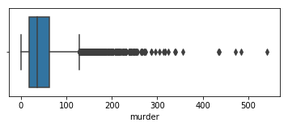

```python
plt.figure(figsize=(6,2))
sb.boxplot(data = india_crimes, x = 'murder');
```

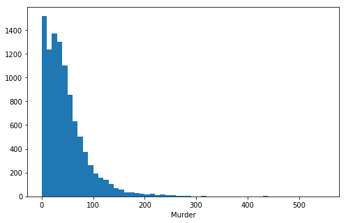

```python
plt.figure(figsize=[8,5])
bin_edges = np.arange(india_crimes.murder.min(), india_crimes.murder.max()+10, 10);
plt.hist(data = india_crimes, x = 'murder', bins = bin_edges);
plt.xlabel('Murder');
plt.show()
```

> Because it's positively skewness we have to take log transformation for the normality.

```python
np.log10(india_crimes.murder.describe())
```

```
count    4.004837
mean     1.667002
std      1.625453
min          -inf
25%      1.255273
50%      1.556303
75%      1.792392
max      2.733999
Name: murder, dtype: float64
```

> **`-inf`** we need to apply machine learning to expunge that weird minimum value. This need to be fix in later time

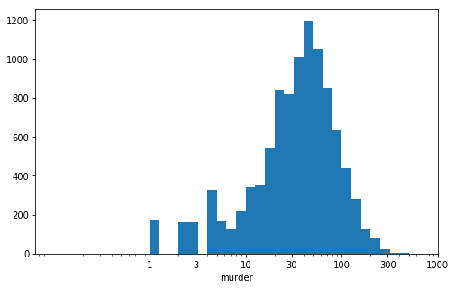

```python
# there's a long tail in the distribution, so let's put it on a log scale instead
plt.figure(figsize=(8,5))
log_bin_width = 0.10
bin_edges = 10 ** np.arange(-1, np.log10(india_crimes['murder'].max())+log_bin_width, log_bin_width)
plt.hist(data = india_crimes, x = 'murder', bins = bin_edges)
plt.xscale('log')
plt.xticks([1, 3, 10, 30, 100, 300, 1000], [1, 3, 10, 30, 100, 300, 1000])
plt.xlabel('murder')
plt.show()
```

> Murders has a long-tailed distribution, by taking log transformation it becomes the normally distributed. The murder happen between 40 and 70 on the peak

```python
np.log10(india_crimes['kidnapping_and_abduction_of_women_and_girls'].describe())
```

```
count    4.004837
mean     1.535421
std      1.693355
min          -inf
25%      0.698970
50%      1.255273
75%      1.633468
max      2.730782
Name: kidnapping_and_abduction_of_women_and_girls, dtype: float64
```

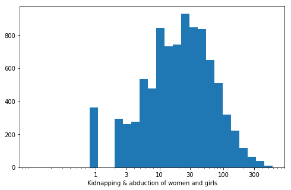

```python
plt.figure(figsize = (8, 5))
# plt.subplot(1,2,1)
log_bin_width = 0.13
bin_edges = 10 ** np.arange(-1, np.log10(india_crimes['kidnapping_and_abduction_of_women_and_girls'].max())+log_bin_width, log_bin_width)
plt.hist(data = india_crimes, x = 'kidnapping_and_abduction_of_women_and_girls', bins = bin_edges);
plt.xscale('log')
plt.xticks([1, 3, 10, 30, 100, 300], [1, 3, 10, 30, 100, 300])
plt.xlabel('Kidnapping & abduction of women and girls');
# plt.xlim(3, 300)
```

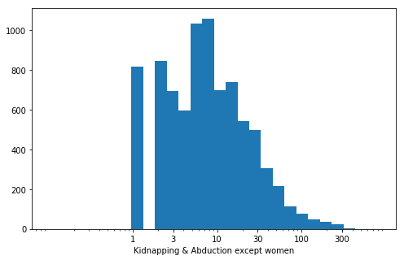

```python
plt.figure(figsize = (8, 5))
log_bin_width = 0.14
# plt.subplot(1,2,1)
bin_edges = 10 ** np.arange(-1, np.log10(india_crimes['kidnapping_and_abduction_of_others'].max())+log_bin_width, log_bin_width)
plt.hist(data = india_crimes, x = 'kidnapping_and_abduction_of_others', bins = bin_edges);
plt.xscale('log')
plt.xticks([1, 3, 10, 30, 100, 300], [1, 3, 10, 30, 100, 300])
plt.xlabel('Kidnapping & Abduction except women');
```

As you can see above two histogram Kidnapping & Abduction of Women and Girls are more widely spread than Kidnapping and abduction of others. The kidnapping of women and girls are between 15 to 80 spread out whereas others are 4 to 20. This is significant outrages against the women in India.

```python
# Color and Order
base_color = sb.color_palette()[0]
states_counts = india_crimes.states_or_union_territories.value_counts()
order_states = states_counts.index
n_crimes = india_crimes.shape[0]
```

```python
states_counts.shape[0]
```

```
36
```

```python
# https://stackoverflow.com/questions/31074758/how-to-set-a-different-color-to-the-largest-bar-in-a-seaborn-barplot

clrs = [base_color if (x < max(states_counts)) else 'darkred' for x in states_counts ]
# sb.barplot(x=idx, y=values, palette=clrs) # color=clrs)
```

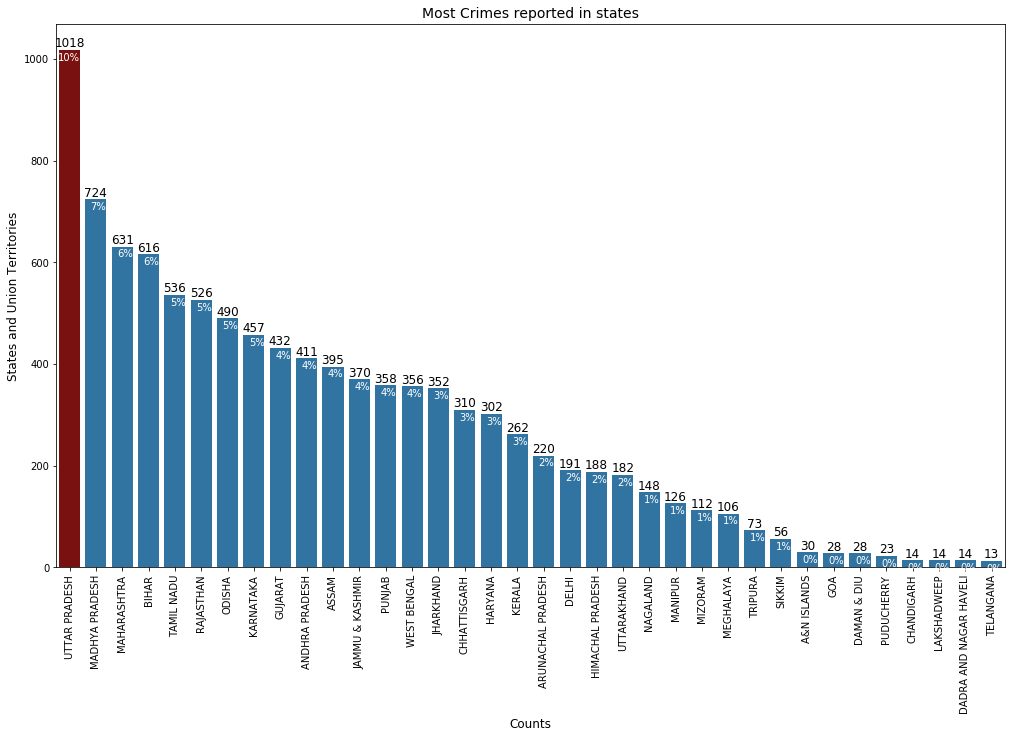

```python
# https://stackoverflow.com/questions/28931224/adding-value-labels-on-a-matplotlib-bar-chart

# Plotting
plt.figure(figsize = (17, 10))
ax = sb.countplot(data = india_crimes, x = 'states_or_union_territories', palette = clrs, order = order_states);
plt.xticks(rotation = 90)
plt.xlabel('Counts', fontsize = 12)
plt.ylabel('States and Union Territories', fontsize = 12)
plt.title('Most Crimes reported in states', fontsize = 14);


perc_list = []

# Calculating the percentage for each states
states_sum = india_crimes['states_or_union_territories'].value_counts().to_list()

for i in range(0, len(states_sum)):
    percent = int(round(100*states_sum[i]/n_crimes))
    perc_list.append(percent)


# Annotation adding on top of the bar and percentage
i = 0
for p in ax.patches:
    ax.annotate('{:.0f}'.format(p.get_height()),
               (p.get_x()+p.get_width()/2, p.get_height()),
               ha='center', va = 'bottom', color = 'black', size = 12)

    ax.annotate('{:.0f}%'.format(perc_list[i]),
                (p.get_x()+p.get_width()/2+0.4, p.get_height()-5),
                ha="right", va="top", color='white', size=10)
    i+=1
```

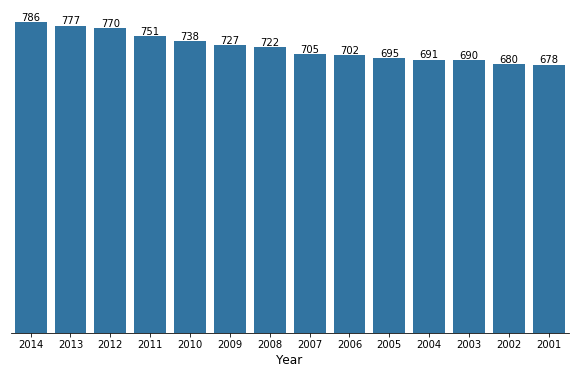

```python
fig = plt.figure(figsize = (10, 6))
# fig, ax = plt.subplots(figsize = (10,6))
states_order = india_crimes.year.value_counts().index
ax = sb.countplot(data = india_crimes, x = 'year', color = base_color, order = states_order)
plt.xlabel('Year', fontsize = 12)
# plt.ylabel('Crimes Count', fontsize = 12)


perc_list = []
year_sum = india_crimes.year.value_counts().to_list()

for i in range(0, len(year_sum)):
    percent = int(round(100*year_sum[i]/n_crimes))
    perc_list.append(percent)

# Calling function Annotation each bar
annotation(ax)



# https://stackoverflow.com/questions/37835591/matplotlib-pyplot-deactivate-axes-in-figure-axis-of-figure-overlap-with-axes
# Removing the axis
remove_axis()
```

### Year Distribution of crimes

> Above graph insinuates crimes incrasing the year by year. There is no mitigation showing of crimes in between year.

```python
india_crimes[india_crimes['district'] == 'LUCKNOW']
```

|  | states_or_union_territories | district | year | murder | rape | kidnapping_and_abduction_of_women_and_girls | kidnapping_and_abduction_of_others | dacoity | robbery | thefts | riots | criminal_breach_of_trust | cheating | arson | hurt_or_grievous_hurt | dowry_deaths | assault_on_women_with_intent_to_outrage_her_modesty | insult_to_modesty_of_women | cruelty_by_husband_or_his_relatives | causing_death_by_negligence | total_ipc_crimes |
| --- | --- | --- | --- | --- | --- | --- | --- | --- | --- | --- | --- | --- | --- | --- | --- | --- | --- | --- | --- | --- | --- |
| 598 | UTTAR PRADESH | LUCKNOW | 2001 | 166 | 62 | 138 | 37 | 28 | 123 | 2202 | 347 | 268 | 427 | 10 | 89 | 47 | 103 | 148 | 337 | 337 | 9205 |
| 1276 | UTTAR PRADESH | LUCKNOW | 2002 | 175 | 43 | 147 | 48 | 23 | 145 | 2210 | 219 | 190 | 358 | 16 | 85 | 59 | 92 | 105 | 369 | 327 | 8622 |
| 1966 | UTTAR PRADESH | LUCKNOW | 2003 | 176 | 38 | 98 | 20 | 10 | 114 | 1753 | 108 | 168 | 300 | 8 | 78 | 29 | 63 | 302 | 216 | 298 | 6806 |
| 2657 | UTTAR PRADESH | LUCKNOW | 2004 | 173 | 46 | 135 | 29 | 12 | 109 | 2279 | 150 | 199 | 325 | 7 | 71 | 48 | 64 | 152 | 272 | 358 | 7412 |
| 3352 | UTTAR PRADESH | LUCKNOW | 2005 | 194 | 51 | 136 | 14 | 8 | 102 | 2340 | 244 | 232 | 432 | 1 | 64 | 44 | 71 | 204 | 281 | 392 | 8007 |
| 4054 | UTTAR PRADESH | LUCKNOW | 2006 | 167 | 51 | 164 | 41 | 7 | 241 | 2296 | 267 | 210 | 464 | 2 | 63 | 39 | 100 | 160 | 374 | 420 | 8102 |
| 4759 | UTTAR PRADESH | LUCKNOW | 2007 | 159 | 82 | 216 | 44 | 32 | 221 | 2642 | 299 | 357 | 779 | 3 | 58 | 57 | 98 | 159 | 513 | 478 | 10017 |
| 5476 | UTTAR PRADESH | LUCKNOW | 2008 | 130 | 82 | 331 | 58 | 17 | 147 | 3100 | 441 | 589 | 1140 | 3 | 57 | 62 | 226 | 340 | 778 | 490 | 13707 |
| 6203 | UTTAR PRADESH | LUCKNOW | 2009 | 114 | 56 | 306 | 17 | 15 | 101 | 2533 | 244 | 498 | 915 | 2 | 48 | 53 | 178 | 256 | 664 | 503 | 12424 |
| 6940 | UTTAR PRADESH | LUCKNOW | 2010 | 114 | 75 | 320 | 8 | 15 | 105 | 2832 | 213 | 460 | 849 | 1 | 46 | 66 | 155 | 0 | 745 | 481 | 12454 |
| 7688 | UTTAR PRADESH | LUCKNOW | 2011 | 119 | 55 | 283 | 9 | 11 | 61 | 2167 | 182 | 392 | 790 | 11 | 43 | 48 | 142 | 0 | 511 | 493 | 10538 |
| 8453 | UTTAR PRADESH | LUCKNOW | 2012 | 141 | 48 | 304 | 11 | 8 | 63 | 2462 | 195 | 411 | 952 | 3 | 91 | 32 | 110 | 2 | 538 | 481 | 11083 |
| 9230 | UTTAR PRADESH | LUCKNOW | 2013 | 133 | 76 | 375 | 6 | 11 | 69 | 2613 | 165 | 538 | 1077 | 4 | 38 | 60 | 360 | 1 | 920 | 488 | 13583 |
| 10016 | UTTAR PRADESH | LUCKNOW | 2014 | 132 | 68 | 90 | 6 | 7 | 60 | 3192 | 174 | 511 | 923 | 14 | 0 | 52 | 392 | 0 | 1083 | 533 | 15107 |

```python
orders = india_crimes.district.value_counts().head(10).index
```

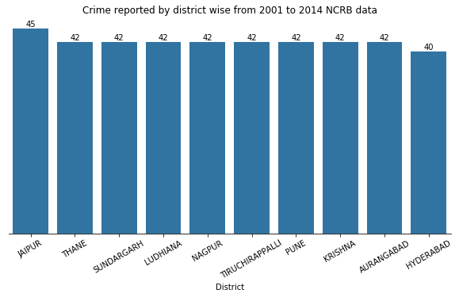

```python
fig = plt.figure(figsize=(10, 5))
ax = sb.countplot(data = india_crimes, x = 'district', color = sb.color_palette()[0], order = orders);
plt.xticks(rotation = 30)
plt.xlabel('District')
plt.ylabel('Counts')
plt.title('Crime reported by district wise from 2001 to 2014 NCRB data')

# Annotation on the bar
annotation(ax)

# Removing the axis
remove_axis()
```

This above graph we take top 10 district that represent just how much crime reported from each district. However, it does not mean highest crime in those district. We will look in bivariant and mulitvariant model that how releated with each state, district, and year to other quantatitve crime variables.

```python
india_crimes.total_ipc_crimes.describe()
```

```
count    10112.000000
mean      2910.463904
std       3234.324455
min          1.000000
25%        858.000000
50%       2094.000000
75%       3923.250000
max      40361.000000
Name: total_ipc_crimes, dtype: float64
```

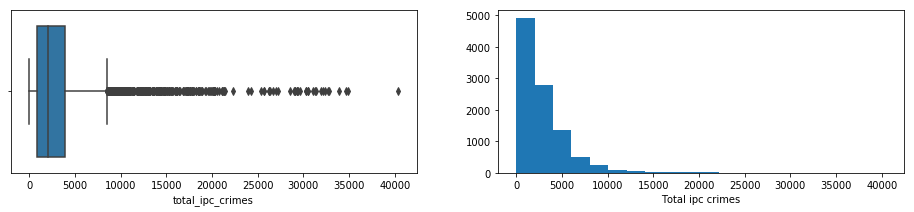

```python
plt.figure(figsize = (16, 3))
plt.subplot(1,2,1)
sb.boxplot(data = india_crimes, x = 'total_ipc_crimes', color = base_color);
# plt.xlim(0, 10000)

plt.subplot(1,2,2)
bins = np.arange(1, india_crimes.total_ipc_crimes.max()+2018, 2018)
plt.hist(data = india_crimes, x = 'total_ipc_crimes', bins = bins);
plt.xlabel('Total ipc crimes');
```

There are lots of outlier in `total_ipc_crimes`. There are two possible way we can see the trends. First, we need to select data into the ranges 0 to 9000. Second, we can do log transormation to consider outlier as the plot. we will perform both of them to see clear picture.

```python
india_crimes_ipc = india_crimes.query('total_ipc_crimes <= 9000')
```

```python
np.log10(india_crimes.total_ipc_crimes.describe())
```

```
count    4.004837
mean     3.463962
std      3.509784
min      0.000000
25%      2.933487
50%      3.320977
75%      3.593646
max      4.605962
Name: total_ipc_crimes, dtype: float64
```

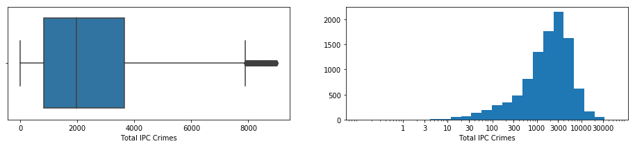

```python
plt.figure(figsize = (16, 3))
plt.subplot(1,2,1)
sb.boxplot(data = india_crimes_ipc, x = 'total_ipc_crimes', color = base_color);
plt.xlabel('Total IPC Crimes');

plt.subplot(1,2,2)
bins = 10 ** np.arange(-1, np.log10(india_crimes.total_ipc_crimes.max())+0.23, 0.23)
plt.hist(data = india_crimes, x = 'total_ipc_crimes', bins = bins);
plt.xscale('log')
plt.xticks([1, 3, 10, 30, 100, 300, 1000, 3000, 10000, 30000], [1, 3, 10, 30, 100, 300, 1000, 3000, 10000, 30000])
plt.xlabel('Total IPC Crimes');
plt.show()
```

The box plot depicts `total ipc crimes` clear ranges between 1000 and 3700 but after third quartile it doesn't show the distribution of data whereas the histogram shows the ranges lie between 1000 and less than 4000. It explicit normally distributed the data after the log transformation.

```python
india_crimes.columns
```

```
Index(['states_or_union_territories', 'district', 'year', 'murder', 'rape',
       'kidnapping_and_abduction_of_women_and_girls',
       'kidnapping_and_abduction_of_others', 'dacoity', 'robbery', 'thefts',
       'riots', 'criminal_breach_of_trust', 'cheating', 'arson',
       'hurt_or_grievous_hurt', 'dowry_deaths',
       'assault_on_women_with_intent_to_outrage_her_modesty',
       'insult_to_modesty_of_women', 'cruelty_by_husband_or_his_relatives',
       'causing_death_by_negligence', 'total_ipc_crimes'],
      dtype='object')
```

### IPC crimes against women:

1. `rape`: Rape is a type of sexual assault usually involving sexual intercourse against a person without that person's consent.
2. `dowry death`: Dowry deaths are deaths of married women who are murdered or driven to suicide by continuous harassment and torture by their husbands
3. `assault_on_women_with_intent_to_outrage_her_modesty`: Assault on women because she belongs to the lower class background and lower cast in the society.
4. `insult_to_modesty_of_women`: Insult to the women because she belongs to the lower class and lower cast background in the society.
5. `cruelty_by_husband_or_his_relatives`: Physically and Mentally reprimand to the women after marriage by her husbend and relative.

#### 1. Rape

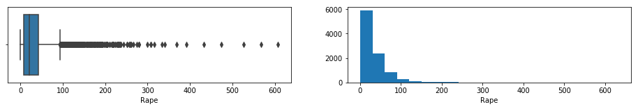

```python
plt.figure(figsize = (16, 2))
plt.subplot(1,2,1)
sb.boxplot(data = india_crimes, x = 'rape', color = base_color);
plt.xlabel('Rape');
# plt.xlim(0, 10000)

plt.subplot(1,2,2)
bins = np.arange(1, india_crimes.rape.max()+30, 30)
plt.hist(data = india_crimes, x = 'rape', bins = bins);
plt.xlabel('Rape');
```

> Box plot shows outliers and histogram has positively skews those are needed transformation tehcnique.

#### Log Transformation

```python
india_crimes_rape = india_crimes.query('rape<=100')
```

```python
np.log10(india_crimes.rape.describe())
```

```
count    4.004837
mean     1.488611
std      1.544952
min          -inf
25%      0.903090
50%      1.322219
75%      1.623249
max      2.783189
Name: rape, dtype: float64
```

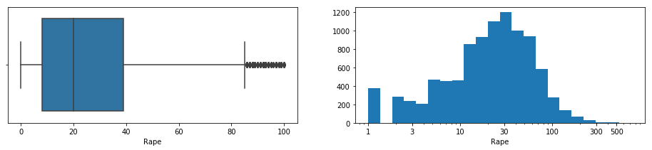

```python
plt.figure(figsize = (16, 3))
plt.subplot(1,2,1)
sb.boxplot(data = india_crimes_rape, x = 'rape', color = base_color);
plt.xlabel('Rape');

plt.subplot(1,2,2)
bins = 10 ** np.arange(0, np.log10(india_crimes.rape.max())+0.13, 0.13)
plt.hist(data = india_crimes, x = 'rape', bins = bins);
plt.xscale('log')
plt.xticks([1, 3, 10, 30, 100, 300, 500], [1, 3, 10, 30, 100, 300, 500])
plt.xlabel('Rape');
plt.show()
```

> The box plot depicts `rape` ranges between 10 and 40 whereas the histogram shows the ranges lie between 15 and less than 50 and average shows 30. Also, looks bell curve.

#### 2. Dowry Death

```python
np.log10(india_crimes.dowry_deaths.describe())
```

```
count    4.004837
mean     1.027544
std      1.156237
min          -inf
25%      0.000000
50%      0.698970
75%      1.176091
max      2.250420
Name: dowry_deaths, dtype: float64
```

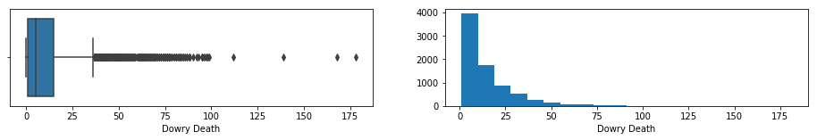

```python
plt.figure(figsize = (16, 2))
plt.subplot(1,2,1)
sb.boxplot(data = india_crimes, x = 'dowry_deaths', color = base_color);
plt.xlabel('Dowry Death');

plt.subplot(1,2,2)
bins = np.arange(1, india_crimes.dowry_deaths.max()+9, 9)
plt.hist(data = india_crimes, x = 'dowry_deaths', bins = bins);
plt.xlabel('Dowry Death');
```

#### Log Transformation

```python
india_crimes_dowry_deaths = india_crimes.query('dowry_deaths<=40')
```

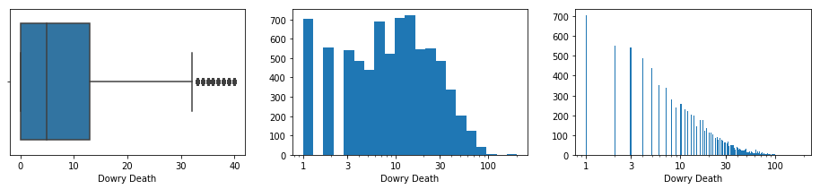

```python
plt.figure(figsize = (16, 3))
plt.subplot(1,3,1)
sb.boxplot(data = india_crimes_dowry_deaths, x = 'dowry_deaths', color = base_color);
plt.xlabel('Dowry Death');

plt.subplot(1,3,2)
bins = 10 ** np.arange(0, np.log10(india_crimes.dowry_deaths.max())+0.11, 0.11)
plt.hist(data = india_crimes, x = 'dowry_deaths', bins = bins);
plt.xscale('log')
plt.xticks([1, 3, 10, 30, 100], [1, 3, 10, 30, 100])
plt.xlabel('Dowry Death');

plt.subplot(1,3,3)
bins = 10 ** np.arange(0, np.log10(india_crimes.dowry_deaths.max())+0.01, 0.01)
plt.hist(data = india_crimes, x = 'dowry_deaths', bins = bins);
plt.xscale('log')
plt.xticks([1, 3, 10, 30, 100], [1, 3, 10, 30, 100])
plt.xlabel('Dowry Death');
```

> After transformation, box plot show clearly data ranges while histogram takes narrow look there is a large spike around a single decimal value, then a gradual tailing off to the right until the next spike.

#### 3. Assault on women with intent to outrage her modesty

```python
np.log10(india_crimes.assault_on_women_with_intent_to_outrage_her_modesty.describe())
```

```
count    4.004837
mean     1.777799
std      1.890419
min          -inf
25%      1.000000
50%      1.518514
75%      1.903090
max      3.211121
Name: assault_on_women_with_intent_to_outrage_her_modesty, dtype: float64
```

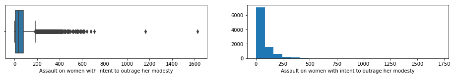

```python
plt.figure(figsize = (16, 2))
plt.subplot(1,2,1)
sb.boxplot(data = india_crimes, x = 'assault_on_women_with_intent_to_outrage_her_modesty', color = base_color);
plt.xlabel('Assault on women with intent to outrage her modesty');

plt.subplot(1,2,2)
bins = np.arange(1, india_crimes.assault_on_women_with_intent_to_outrage_her_modesty.max()+81, 81)
plt.hist(data = india_crimes, x = 'assault_on_women_with_intent_to_outrage_her_modesty', bins = bins);
plt.xlabel('Assault on women with intent to outrage her modesty');
```

#### Log Transformation

```python
india_crimes_assault_women = india_crimes.query('assault_on_women_with_intent_to_outrage_her_modesty<=150')
```

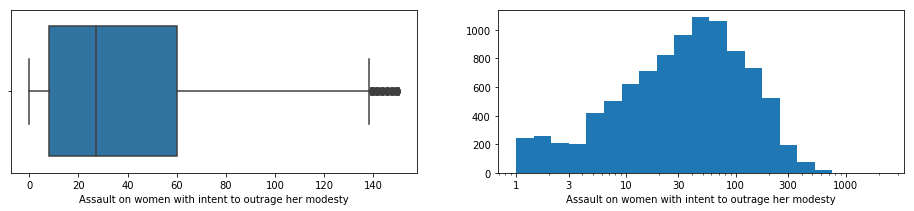

```python
plt.figure(figsize = (16, 3))
plt.subplot(1,2,1)
sb.boxplot(data = india_crimes_assault_women, x = 'assault_on_women_with_intent_to_outrage_her_modesty', color = base_color);
plt.xlabel('Assault on women with intent to outrage her modesty');

plt.subplot(1,2,2)
bins = 10 ** np.arange(0, np.log10(india_crimes.assault_on_women_with_intent_to_outrage_her_modesty.max())+0.16, 0.16)
plt.hist(data = india_crimes, x = 'assault_on_women_with_intent_to_outrage_her_modesty', bins = bins);
plt.xscale('log')
plt.xticks([1, 3, 10, 30, 100, 300, 1000], [1, 3, 10, 30, 100, 300, 1000])
plt.xlabel('Assault on women with intent to outrage her modesty');
```

> `Assault on women with intent to outrage her modesty` taking $<=150$ values for removing outliers and after transformation histogram appears **unimodel shape where we can see data dense between 30 and 80.**

#### 4. Insult to modesty of women

```python
np.log10(india_crimes.insult_to_modesty_of_women.describe())
```

```
count    4.004837
mean     1.160600
std      1.647833
min          -inf
25%          -inf
50%      0.000000
75%      1.041393
max      3.099335
Name: insult_to_modesty_of_women, dtype: float64
```

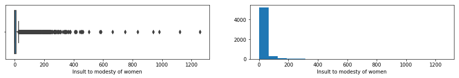

```python
plt.figure(figsize = (16, 2))
plt.subplot(1,2,1)
sb.boxplot(data = india_crimes, x = 'insult_to_modesty_of_women', color = base_color);
plt.xlabel('Insult to modesty of women');

plt.subplot(1,2,2)
bins = np.arange(1, india_crimes.insult_to_modesty_of_women.max()+63, 63)
plt.hist(data = india_crimes, x = 'insult_to_modesty_of_women', bins = bins);
plt.xlabel('Insult to modesty of women');
```

#### Log Transformation

```python
india_crimes_modest_women = india_crimes.query('insult_to_modesty_of_women<=40')
```

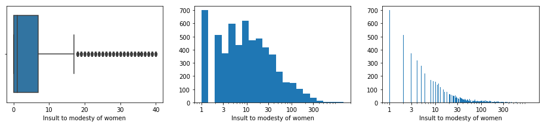

```python
plt.figure(figsize = (16, 3))
plt.subplot(1,3,1)
sb.boxplot(data = india_crimes_modest_women, x = 'insult_to_modesty_of_women', color = base_color);
plt.xlabel('Insult to modesty of women');

plt.subplot(1,3,2)
bins = 10 ** np.arange(0, np.log10(india_crimes.insult_to_modesty_of_women.max())+0.15, 0.15)
plt.hist(data = india_crimes, x = 'insult_to_modesty_of_women', bins = bins);
plt.xscale('log')
plt.xticks([1, 3, 10, 30, 100, 300], [1, 3, 10, 30, 100, 300])
plt.xlabel('Insult to modesty of women');

plt.subplot(1,3,3)
bins = 10 ** np.arange(0, np.log10(india_crimes.insult_to_modesty_of_women.max())+0.01, 0.01)
plt.hist(data = india_crimes, x = 'insult_to_modesty_of_women', bins = bins);
plt.xscale('log')
plt.xticks([1, 3, 10, 30, 100, 300], [1, 3, 10, 30, 100, 300])
plt.xlabel('Insult to modesty of women');
```

#### 5. Cruelty by husbend or his relatives

```python
np.log10(india_crimes.cruelty_by_husband_or_his_relatives.describe())
```

```
count    4.004837
mean     2.043229
std      2.287876
min          -inf
25%      1.079181
50%      1.698970
75%      2.130334
max      3.549739
Name: cruelty_by_husband_or_his_relatives, dtype: float64
```

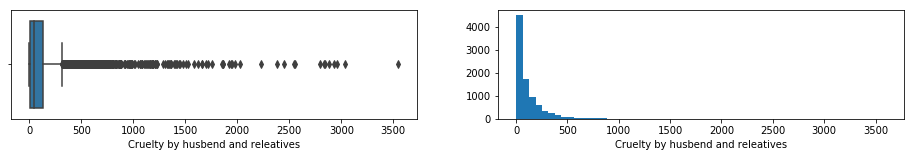

```python
plt.figure(figsize = (16, 2))
plt.subplot(1,2,1)
sb.boxplot(data = india_crimes, x = 'cruelty_by_husband_or_his_relatives', color = base_color);
plt.xlabel('Cruelty by husbend and releatives');

plt.subplot(1,2,2)
bins = np.arange(1, india_crimes.cruelty_by_husband_or_his_relatives.max()+63, 63)
plt.hist(data = india_crimes, x = 'cruelty_by_husband_or_his_relatives', bins = bins);
plt.xlabel('Cruelty by husbend and releatives');
```

#### Log Transformation

```python
india_crimes_women_cruel = india_crimes.query('cruelty_by_husband_or_his_relatives<=270')
```

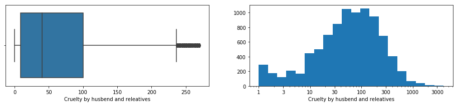

```python
plt.figure(figsize = (16, 3))
plt.subplot(1,2,1)
sb.boxplot(data = india_crimes_women_cruel, x = 'cruelty_by_husband_or_his_relatives', color = base_color);
plt.xlabel('Cruelty by husbend and releatives');

plt.subplot(1,2,2)
bins = 10 ** np.arange(0, np.log10(india_crimes.cruelty_by_husband_or_his_relatives.max())+0.18, 0.18)
plt.hist(data = india_crimes, x = 'cruelty_by_husband_or_his_relatives', bins = bins);
plt.xscale('log')
plt.xticks([1, 3, 10, 30, 100, 300, 1000, 3000], [1, 3, 10, 30, 100, 300, 1000, 3000])
plt.xlabel('Cruelty by husbend and releatives');
```

```python
india_crimes.district.nunique()
```

```
710
```

```python
india_crimes.head()
```

|  | states_or_union_territories | district | year | murder | rape | kidnapping_and_abduction_of_women_and_girls | kidnapping_and_abduction_of_others | dacoity | robbery | thefts | riots | criminal_breach_of_trust | cheating | arson | hurt_or_grievous_hurt | dowry_deaths | assault_on_women_with_intent_to_outrage_her_modesty | insult_to_modesty_of_women | cruelty_by_husband_or_his_relatives | causing_death_by_negligence | total_ipc_crimes |
| --- | --- | --- | --- | --- | --- | --- | --- | --- | --- | --- | --- | --- | --- | --- | --- | --- | --- | --- | --- | --- | --- |
| 0 | ANDHRA PRADESH | ADILABAD | 2001 | 101 | 50 | 30 | 16 | 9 | 41 | 199 | 78 | 16 | 104 | 30 | 1131 | 16 | 149 | 34 | 175 | 181 | 4154 |
| 1 | ANDHRA PRADESH | ANANTAPUR | 2001 | 151 | 23 | 30 | 23 | 8 | 16 | 366 | 168 | 11 | 65 | 69 | 1543 | 7 | 118 | 24 | 154 | 270 | 4125 |
| 2 | ANDHRA PRADESH | CHITTOOR | 2001 | 101 | 27 | 34 | 25 | 4 | 14 | 723 | 156 | 33 | 209 | 38 | 2088 | 14 | 112 | 83 | 186 | 404 | 5818 |
| 3 | ANDHRA PRADESH | KADAPA | 2001 | 80 | 20 | 20 | 5 | 1 | 4 | 173 | 164 | 12 | 37 | 23 | 795 | 17 | 126 | 38 | 57 | 233 | 3140 |
| 4 | ANDHRA PRADESH | EAST GODAVARI | 2001 | 82 | 23 | 26 | 23 | 4 | 25 | 1021 | 70 | 50 | 220 | 41 | 1244 | 12 | 109 | 58 | 247 | 431 | 6507 |

```python
print(india_crimes.thefts.mean())
print(india_crimes.thefts.std())
```

```
425.8370253164557
826.4004031278988
```

```python
np.log10(india_crimes.thefts.describe())
```

```
count    4.004837
mean     2.629243
std      2.917191
min          -inf
25%      1.943247
50%      2.326336
75%      2.644439
max      4.120409
Name: thefts, dtype: float64
```

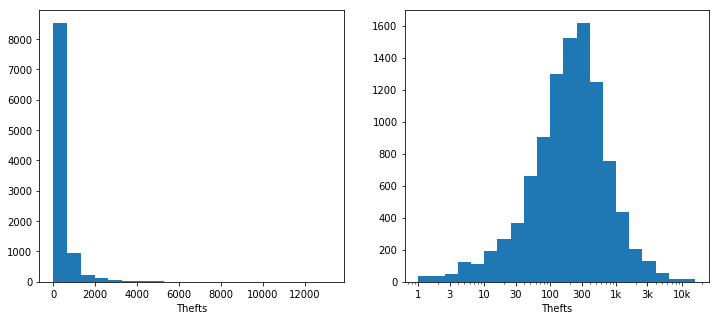

```python
plt.figure(figsize=(12,5))
plt.subplot(1,2,1)
bins = np.arange(1, 13195+660, 660)
plt.hist(data = india_crimes, x = 'thefts', bins = bins);
plt.xlabel('Thefts');

# After the log transformation
plt.subplot(1,2,2)
bins = 10**np.arange(0, np.log10(india_crimes.thefts.max())+0.2, 0.2)
plt.hist(data = india_crimes, x = 'thefts', bins = bins);
plt.xscale('log');
x_ticks = [1, 3, 10, 30, 100, 300, 1000, 3000, 10000]

# xticks and xticks labels
plt.xticks(x_ticks, [1, 3, 10, 30, 100, 300, '1k', '3k', '10k']);
plt.xlabel('Thefts');
```

```python
india_crimes.info()
```

```
<class 'pandas.core.frame.DataFrame'>
RangeIndex: 10112 entries, 0 to 10111
Data columns (total 21 columns):
 #   Column                                               Non-Null Count  Dtype
---  ------                                               --------------  -----
 0   states_or_union_territories                          10112 non-null  object
 1   district                                             10112 non-null  object
 2   year                                                 10112 non-null  category
 3   murder                                               10112 non-null  int64
 4   rape                                                 10112 non-null  int64
 5   kidnapping_and_abduction_of_women_and_girls          10112 non-null  int64
 6   kidnapping_and_abduction_of_others                   10112 non-null  int64
 7   dacoity                                              10112 non-null  int64
 8   robbery                                              10112 non-null  int64
 9   thefts                                               10112 non-null  int64
 10  riots                                                10112 non-null  int64
 11  criminal_breach_of_trust                             10112 non-null  int64
 12  cheating                                             10112 non-null  int64
 13  arson                                                10112 non-null  int64
 14  hurt_or_grievous_hurt                                10112 non-null  int64
 15  dowry_deaths                                         10112 non-null  int64
 16  assault_on_women_with_intent_to_outrage_her_modesty  10112 non-null  int64
 17  insult_to_modesty_of_women                           10112 non-null  int64
 18  cruelty_by_husband_or_his_relatives                  10112 non-null  int64
 19  causing_death_by_negligence                          10112 non-null  int64
 20  total_ipc_crimes                                     10112 non-null  int64
dtypes: category(1), int64(18), object(2)
memory usage: 1.6+ MB
```

### Discuss the distribution(s) of your variable(s) of interest. Were there any unusual points? Did you need to perform any transformations?

1. `murder` has outliers. In order to see to fix that we have done log transformation that shows similar gaussian distribution.
2. `kidnapping and abudction` of women has outliers. So I need to perform log base 10 transformation.
3. `states and union territores`, I counts how many crime reported in the states wise.
4. `year` wise countplot that measure no. of crimes register in each year.
5. `total ipc crimes` have outliers as we clearly see in the boxplot. Instead of removing, we perform log transformation.
6. `thefts` postively skews. We take log transformation.
7. `district` countplot shows crime reported counts of top 10 district.
8. `IPC crimes against women` variables as **`rape, dowry_deaths, assault_on_women_with_intent_to_outrage_her_modesty, insult_to_modesty_of_women, and cruelty_by_husband_or_his_relatives`** has outlier needs to be perform log transformation.

### Of the features you investigated, were there any unusual distributions? Did you perform any operations on the data to tidy, adjust, or change the form of the data? If so, why did you do this?

#### Quantative variables:

> After performing the log transformion on **`murder, kidnapping and abudction, total ipc crimes, thefts, rape, dowry_deaths, assault_on_women_with_intent_to_outrage_her_modesty, insult_to_modesty_of_women, and cruelty_by_husband_or_his_relatives`**, we adjust the log base bin sizes for nice clairty in the log transformation, then set appropriate labels. Selecting pertinent data ranges for removing the outlier to express clear data.

#### Qualatative variables:

> **`states and union territores, district, year`** countplot I added more clearity throught displaying the numbers at top of the bar and percentage just below of the the edges of the bar. Furthermore, Added color properties wisely to highlight maximum crimes reported in the states wise crimes.

## Bivariate Exploration

> In this section, investigate relationships between pairs of variables in your data. Make sure the variables that you cover here have been introduced in some fashion in the previous section (univariate exploration).

### `Total IPC crimes and states or union territories`

```python
def aggregate_crimes(x, y):
    data = india_crimes.groupby(x)[y].sum().reset_index()
    data = data.sort_values(ascending = True, by= y).reset_index(drop=True)
    return data
```

```python
# crimes_states = india_crimes.groupby('states_or_union_territories')['total_ipc_crimes'].sum().reset_index()
# crimes_states = crimes_states.sort_values(ascending = False, by='total_ipc_crimes').reset_index(drop=True)
crimes_states = aggregate_crimes('states_or_union_territories', 'total_ipc_crimes')
```

```python
crimes_states.head()
```

|  | states_or_union_territories | total_ipc_crimes |
| --- | --- | --- |
| 0 | LAKSHADWEEP | 864 |
| 1 | DAMAN & DIU | 3427 |
| 2 | DADRA AND NAGAR HAVELI | 5242 |
| 3 | SIKKIM | 8909 |
| 4 | A&N ISLANDS | 10460 |

```python
color_base = sb.color_palette()[0]
clrs = [color_base if (x < max(crimes_states.total_ipc_crimes)) else 'darkred' for x in crimes_states.total_ipc_crimes]
```

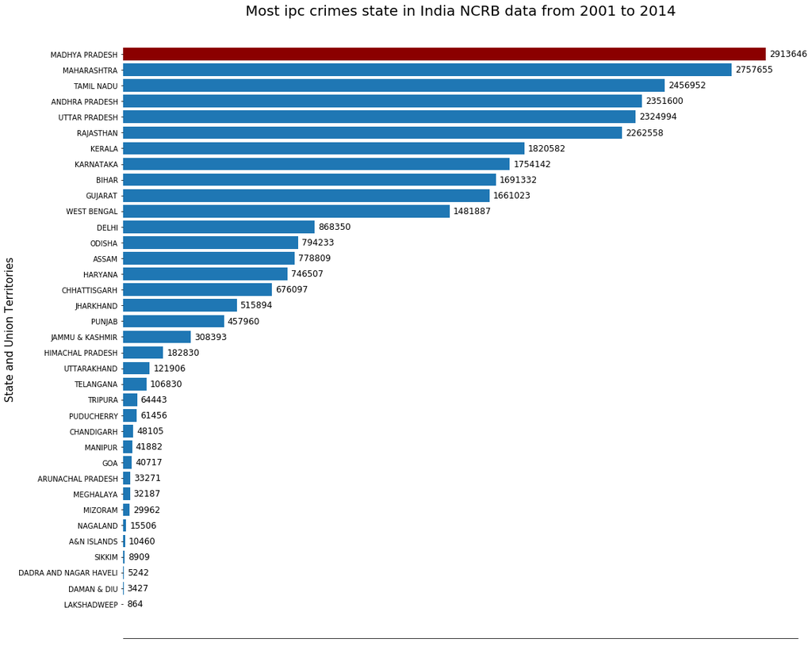

```python
# https://www.tutorialspoint.com/matplotlib/matplotlib_bar_plot.htm

fig = plt.figure(figsize = (17, 16))
x = crimes_states.states_or_union_territories.to_list()
y = crimes_states.total_ipc_crimes.to_list()

ax = plt.barh(x, y, color = clrs)
plt.xticks(rotation = 90);

# For each bar: Place a label

for rect in ax.patches:
    # Get X and Y placement of label from rect.
    x_value = rect.get_width()
    y_value = rect.get_y() + rect.get_height() / 2
    # print(x_value, y_value)

    # Number of points between bar and label. Change to your liking.
    space = 5
    # space_perc = 50
    # Horizintal alignment for positive values
    ha = 'left'

    # If value of bar is negative: Place label left of bar
    if x_value < 0:
        # Invert space to place label to the left
        space *= -1
        # Horizontally align label at right
        ha = 'right'

    # Use X value as label and format number with one decimal place and percentage 2 decimal place
    label = "{:.0f}".format(x_value)
    # label_perc = str(perc_list[i])+'%'

    # Create annotation
    plt.annotate(
        label,                      # Use `label` as label
        (x_value, y_value),         # Place label at end of the bar
        xytext=(space, 0),          # Horizontally shift label by `space`
        textcoords="offset points", # Interpret `xytext` as offset in points
        va='center',                # Vertically center label
        ha=ha,
        color = 'black',            # Horizontally align label differently for
        size = 12)                  # positive and negative values.

#     plt.annotate(
#     label_perc,
#     (perc_list[i], y_value),
#     xytext=(space_perc*10, 0),
#     textcoords="offset points",
#     va="center",
#     ha=ha,
#     color='green',
#     size=12)


# Removing the axes
cur_axes = plt.gca()
# cur_axes.axes.get_yaxis().set_visible(False)
cur_axes.axes.get_xaxis().set_visible(False)
sb.despine(fig, left = True)
plt.title('Most ipc crimes state in India NCRB data from 2001 to 2014', fontsize = 20);
plt.ylabel('State and Union Territories', fontsize = 15);
# plt.savefig("image.png")
```

> Above result showing the total ipc crimes counts and states with pyplot bar chart. It's appropriate to use here instead seaborn countplot. So `Madhya Pradesh` with **2913646** followed by `Maharashtra` and `Tamil Nadu`

```python
ind_total_ipc = india_crimes.query("total_ipc_crimes >= 800 and total_ipc_crimes <5000")
```

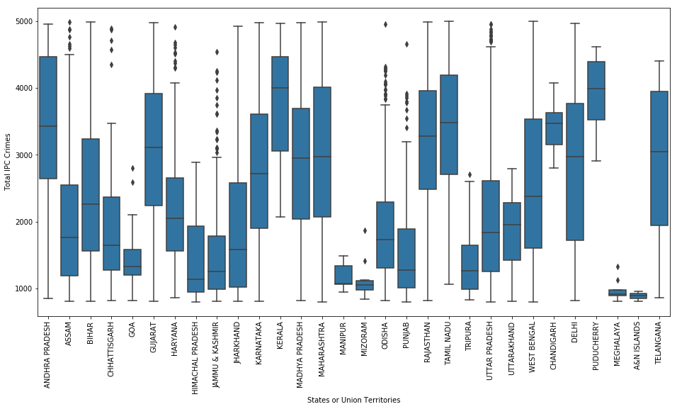

```python
# https://stackoverflow.com/questions/28931224/adding-value-labels-on-a-matplotlib-bar-chart
fig = plt.figure(figsize = (16, 8))
sb.boxplot(data = ind_total_ipc, x = 'states_or_union_territories', y = 'total_ipc_crimes', color = base_color)
plt.xticks(rotation = 90);
plt.ylabel('Total IPC Crimes')
plt.xlabel('States or Union Territories');
```

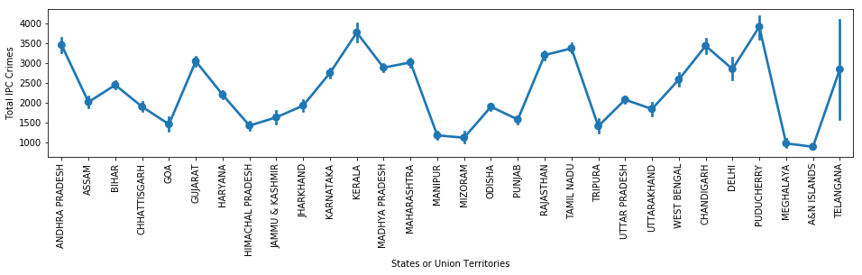

```python
fig = plt.figure(figsize = (16, 3))
sb.pointplot(data = ind_total_ipc, x = 'states_or_union_territories', y = 'total_ipc_crimes')
plt.xticks(rotation = 90)
plt.ylabel('Total IPC Crimes')
plt.xlabel('States or Union Territories');
```

### `District and total_ipc_crimes`

```python
ipc_district = aggregate_crimes('district', 'total_ipc_crimes')
```

```python
dist_top_20 =  ipc_district.tail(20)
```

```python
dist_top_20 = dist_top_20[['district','total_ipc_crimes']].sort_values(by = 'total_ipc_crimes', ascending = False)
```

```python
clrs = [color_base if (x < max(dist_top_20.total_ipc_crimes)) else 'darkred' for x in dist_top_20.total_ipc_crimes]
```

```python
total_ipc = india_crimes.total_ipc_crimes.sum()
```

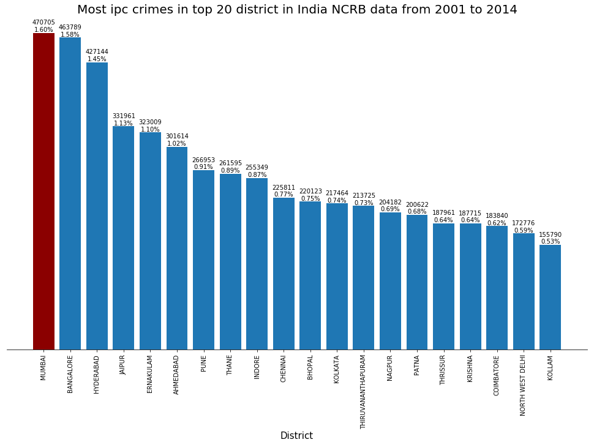

```python
fig = plt.figure(figsize = (17, 10))
x = dist_top_20.district.to_list()
y = dist_top_20.total_ipc_crimes.to_list()

ax = plt.bar(x, y, color = clrs)
plt.xticks(rotation = 90);
plt.xlabel('District', fontsize = 15)
plt.title('Most ipc crimes in top 20 district in India NCRB data from 2001 to 2014', fontsize = 20);

perc_list = []
num_list = dist_top_20.total_ipc_crimes.to_list()

for i in range(0, len(num_list)):
    percent = round(100*num_list[i]/total_ipc, 2)
    perc_list.append(percent)

i = 0
for p in ax.patches:
    plt.annotate('{:.0f}\n{:.2f}%'.format(p.get_height(), perc_list[i]),
                (p.get_x()+p.get_width()/2, p.get_height()),
                color = 'black', va='bottom', ha='center', size=10)
    i+=1


# Removing the axis
remove_axis()
```

### `Above top 20 district average total ipc crimes`

```python
dist_top_20.district.unique()
```

```
array(['MUMBAI', 'BANGALORE', 'HYDERABAD', 'JAIPUR', 'ERNAKULAM',
       'AHMEDABAD', 'PUNE', 'THANE', 'INDORE', 'CHENNAI', 'BHOPAL',
       'KOLKATA', 'THIRUVANANTHAPURAM', 'NAGPUR', 'PATNA', 'THRISSUR',
       'KRISHNA', 'COIMBATORE', 'NORTH WEST DELHI', 'KOLLAM'],
      dtype=object)
```

```python
dist_top20_district = india_crimes[india_crimes.district.isin(['MUMBAI', 'BANGALORE', 'HYDERABAD', 'JAIPUR', 'ERNAKULAM',
       'AHMEDABAD', 'PUNE', 'THANE', 'INDORE', 'CHENNAI', 'BHOPAL',
       'KOLKATA', 'THIRUVANANTHAPURAM', 'NAGPUR', 'PATNA', 'THRISSUR',
       'KRISHNA', 'COIMBATORE', 'NORTH WEST DELHI', 'KOLLAM'])]
```

[figure not shown]

```python
plt.figure(figsize = (16,4))
sb.pointplot(data = dist_top20_district, x = 'district', y = 'total_ipc_crimes')
plt.xticks(rotation = 90);
plt.ylabel('Kidnapping and abduction of women and girls')
plt.xlabel('States or Union Territories');
```

##### Intersting result we can deduce as following:

> Above districts are also know as eminent metropolilation city in india. `Mumbai` district known as most eminent city in the Maharashtra, India has most crimes occured. So we can summerize on the above result, most of the ipc_crimes takes palce in the metropolation area.

```python
crimes_year = india_crimes.groupby('year')['total_ipc_crimes'].sum().reset_index()
crimes_year = crimes_year.sort_values(ascending = False, by='year').reset_index(drop=True)
```

```python
crimes_year
```

|  | year | total_ipc_crimes |
| --- | --- | --- |
| 0 | 2014 | 2857459 |
| 1 | 2013 | 2646949 |
| 2 | 2012 | 2387079 |
| 3 | 2011 | 2325488 |
| 4 | 2010 | 2223963 |
| 5 | 2009 | 2120433 |
| 6 | 2008 | 2092158 |
| 7 | 2007 | 1988348 |
| 8 | 2006 | 1876920 |
| 9 | 2005 | 1820891 |
| 10 | 2004 | 1829622 |
| 11 | 2003 | 1714475 |
| 12 | 2002 | 1778947 |
| 13 | 2001 | 1767879 |

```python
india_crimes.total_ipc_crimes.sum()
```

```
29430611
```

```python
clrs = [color_base if (x < max(crimes_year.year)) else 'darkred' for x in crimes_year.year]
```

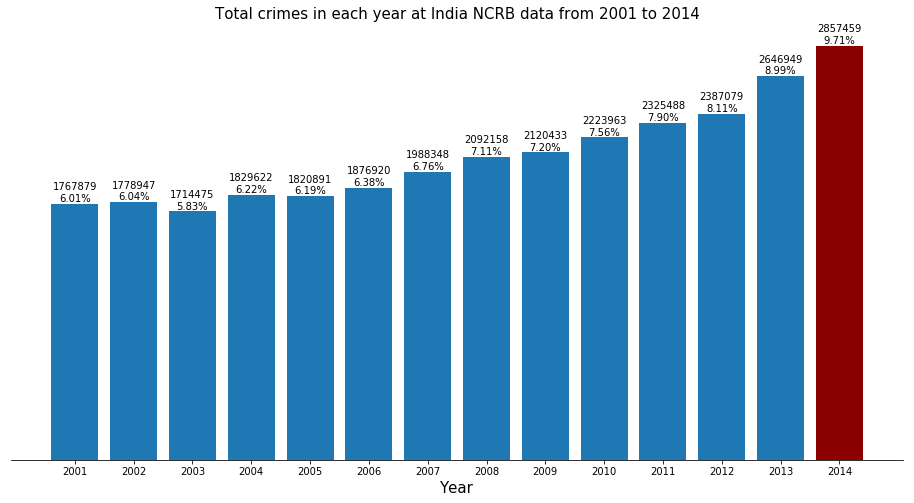

```python
fig = plt.figure(figsize = (16, 8))
x = crimes_year.year.to_list()
y = crimes_year.total_ipc_crimes.to_list()

ax = plt.bar(x, y, color = clrs)
# plt.xticks(rotation = 60)
plt.xlabel('Year', fontsize = 15)
plt.title('Total crimes in each year at India NCRB data from 2001 to 2014', fontsize = 15)
x_ticks = [i for i in range(2001, 2015)]
plt.xticks(x_ticks, x_ticks)

perc_list = []
year_ipc_sum = crimes_year.total_ipc_crimes.to_list()

for i in range(0, len(year_ipc_sum)):
    percent = round(100*year_ipc_sum[i]/india_crimes.total_ipc_crimes.sum(), 2)
    perc_list.append(percent)


annotation_perc(ax, perc_list)


# Removing axes
remove_axis()
```

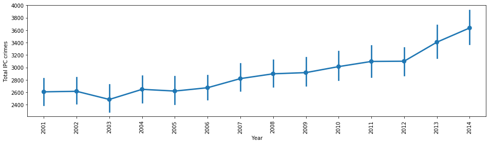

```python
plt.figure(figsize = (16,4))
sb.pointplot(data = india_crimes, x = 'year', y = 'total_ipc_crimes')
plt.xticks(rotation = 90);
plt.ylabel('Total IPC crimes')
plt.xlabel('Year');
```

```python
sample_1 = india_crimes[india_crimes.total_ipc_crimes <= 10000]
```

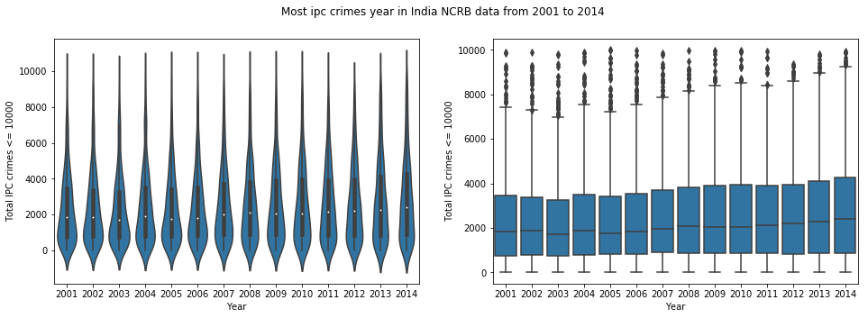

```python
plt.figure(figsize = (16, 5))
plt.subplot(1,2,1)
ax1 = sb.violinplot(data = sample_1, x = 'year', y = 'total_ipc_crimes', color = color_base);
plt.suptitle('Most ipc crimes year in India NCRB data from 2001 to 2014')
plt.xlabel('Year')
plt.ylabel('Total IPC crimes <= 10000');


plt.subplot(1,2,2)
ax2 = sb.boxplot(data = sample_1, x = 'year', y = 'total_ipc_crimes', color = base_color);
plt.xlabel('Year')
plt.ylabel('Total IPC crimes <= 10000');
```

> There is not surprising result the crimes has been increasing every year as we saw in our privous result of univariant crimes report register. But, that was just report and not showing the total ipc crimes. Now, if you take closer look above graph you will find some mitigation between in **year 2003 and 2005** that wasn't in earlier result in univariant. Nonetheless, it's just subtle difference in 2004 and 2005 of 8731 or 0.03%.

```python
india_crimes.states_or_union_territories = india_crimes.states_or_union_territories.astype('object')
```

We are taking top 5 states or union territories and district murder committed.

```python
top5_murder_states = aggregate_crimes('states_or_union_territories', 'murder').tail()
```

```python
top5_murder_district = aggregate_crimes('district', 'murder').tail()
```

```python
clrs = [color_base if (x < max(top5_murder_states.murder)) else 'darkred' for x in top5_murder_states.murder]
```

```python
india_crimes.murder.sum()
```

```
469720
```

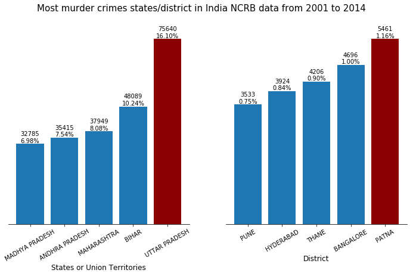

```python
fig = plt.figure(figsize = (12, 6))
plt.subplot(1,2,1)

x = top5_murder_states.states_or_union_territories.to_list()
y = top5_murder_states.murder.to_list()

ax1 = plt.bar(x, y, color = clrs)
plt.xticks(rotation = 30);
plt.xlabel('States or Union Territories', fontsize=12)
plt.suptitle('Most murder crimes states/district in India NCRB data from 2001 to 2014', fontsize = 15);

perc_list_1 = []
num_list_1 = top5_murder_states.murder.to_list()

for i in range(0, len(num_list_1)):
    percent = round(100*num_list_1[i]/india_crimes.murder.sum(), 2)
    perc_list_1.append(percent)
# print(perc_list_1)

# Annotation
annotation_perc(ax1, perc_list_1)

# Removing axes
remove_axis()

plt.subplot(1,2,2)

x = top5_murder_district.district.to_list()
y = top5_murder_district.murder.to_list()

ax2 = plt.bar(x, y, color = clrs)

plt.xticks(rotation = 30);
plt.xlabel('District', fontsize=12)

perc_list_2 = []
num_list_2 = top5_murder_district.murder.to_list()

for j in range(0, len(num_list_2)):
    percent = round(100*num_list_2[j]/india_crimes.murder.sum(), 2)
    perc_list_2.append(percent)

# Annotation
annotation_perc(ax2, perc_list_2)

# Removing axes
remove_axis()
```

[figure not shown]

```python
plt.figure(figsize = (16,4))
sb.pointplot(data = india_crimes, x = 'states_or_union_territories', y = 'murder')
plt.xticks(rotation = 90);
plt.ylabel('Kidnapping and abduction of women and girls')
plt.xlabel('States or Union Territories');
```

`Uttar Pradesh` recorded the most murders at **75,640**. UP was followed by `Bihar`, which recorded **48,089** murders from 2001 to 2014. Next on the state-wise list was `Maharashtra` with **37,949**. In district-wise, `patna` documented **5,461** murder cases followed by `Banglore` with **4,696**, then `Thane`.

We are taking top 5 states or union territories of total ipc crimes

```python
top5_rape_states = aggregate_crimes('states_or_union_territories', 'rape').tail()
```

```python
top5_rape_district = aggregate_crimes('district', 'rape').tail()
```

```python
clrs = [color_base if (x < max(top5_rape_states.rape)) else 'darkred' for x in top5_rape_states.rape]
india_crimes.rape.sum()
```

```
311493
```

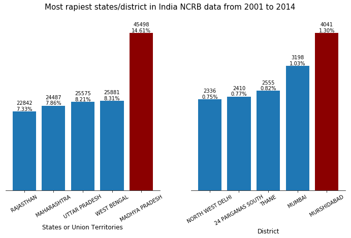

```python
fig = plt.figure(figsize = (12, 6))
plt.subplot(1,2,1)
# ax1 = sb.barplot(data = top5_rape_states, x = 'states_or_union_territories', y = 'rape', palette = clrs)
x = top5_rape_states.states_or_union_territories.to_list()
y = top5_rape_states.rape.to_list()

ax1 = plt.bar(x, y, color = clrs)
plt.xticks(rotation = 30);
plt.xlabel('States or Union Territories', fontsize=12)
plt.suptitle('Most rapiest states/district in India NCRB data from 2001 to 2014', fontsize = 15);

perc_list_1 = []
num_list_1 = top5_rape_states.rape.to_list()

for i in range(0, len(num_list_1)):
    percent = round(100*num_list_1[i]/india_crimes.rape.sum(), 2)
    perc_list_1.append(percent)
# print(perc_list_1)

# Annotation
annotation_perc(ax1, perc_list_1)

# Removing axes
remove_axis()

plt.subplot(1,2,2)
# ax2 = sb.barplot(data = top5_rape_district, x = 'district', y = 'rape', palette = clrs)
x = top5_rape_district.district.to_list()
y = top5_rape_district.rape.to_list()

ax2 = plt.bar(x, y, color = clrs)
plt.xticks(rotation = 30);
plt.xlabel('District', fontsize=12)

perc_list_2 = []
num_list_2 = top5_rape_district.rape.to_list()

for j in range(0, len(num_list_2)):
    percent = round(100*num_list_2[j]/india_crimes.rape.sum(), 2)
    perc_list_2.append(percent)

# Annotation
annotation_perc(ax2, perc_list_2)

# Removing axes
remove_axis()
```

The central state of `Madhya Pradesh` reported the highest number of rape cases across India in from 2001 to 2014, with **45,498**. Then, next states West Bengal, Uttar Pradesh, and Rajasthan followed during the measured time period. On the other hand, `Murshidabad` district most rape recorded with **4,041** followed by Mumbai, Thane, 24 parganas south, North west delhi.

```python
india_crimes.head()
```

|  | states_or_union_territories | district | year | murder | rape | kidnapping_and_abduction_of_women_and_girls | kidnapping_and_abduction_of_others | dacoity | robbery | thefts | riots | criminal_breach_of_trust | cheating | arson | hurt_or_grievous_hurt | dowry_deaths | assault_on_women_with_intent_to_outrage_her_modesty | insult_to_modesty_of_women | cruelty_by_husband_or_his_relatives | causing_death_by_negligence | total_ipc_crimes |
| --- | --- | --- | --- | --- | --- | --- | --- | --- | --- | --- | --- | --- | --- | --- | --- | --- | --- | --- | --- | --- | --- |
| 0 | ANDHRA PRADESH | ADILABAD | 2001 | 101 | 50 | 30 | 16 | 9 | 41 | 199 | 78 | 16 | 104 | 30 | 1131 | 16 | 149 | 34 | 175 | 181 | 4154 |
| 1 | ANDHRA PRADESH | ANANTAPUR | 2001 | 151 | 23 | 30 | 23 | 8 | 16 | 366 | 168 | 11 | 65 | 69 | 1543 | 7 | 118 | 24 | 154 | 270 | 4125 |
| 2 | ANDHRA PRADESH | CHITTOOR | 2001 | 101 | 27 | 34 | 25 | 4 | 14 | 723 | 156 | 33 | 209 | 38 | 2088 | 14 | 112 | 83 | 186 | 404 | 5818 |
| 3 | ANDHRA PRADESH | KADAPA | 2001 | 80 | 20 | 20 | 5 | 1 | 4 | 173 | 164 | 12 | 37 | 23 | 795 | 17 | 126 | 38 | 57 | 233 | 3140 |
| 4 | ANDHRA PRADESH | EAST GODAVARI | 2001 | 82 | 23 | 26 | 23 | 4 | 25 | 1021 | 70 | 50 | 220 | 41 | 1244 | 12 | 109 | 58 | 247 | 431 | 6507 |

```python
top5_thefts_states = aggregate_crimes('states_or_union_territories', 'thefts').tail()
```

```python
top5_thefts_district = aggregate_crimes('district', 'thefts').tail()
```

```python
clrs = [color_base if (x < max(top5_thefts_states.thefts)) else 'darkred' for x in top5_thefts_states.thefts]
india_crimes.thefts.sum()
```

```
4306064
```

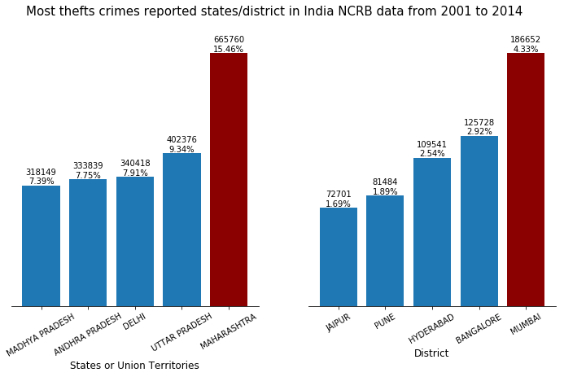

```python
fig = plt.figure(figsize = (12, 6))
plt.subplot(1,2,1)
# ax1 = sb.barplot(data = top5_thefts_states, x = 'states_or_union_territories', y = 'thefts', palette = clrs)
x = top5_thefts_states.states_or_union_territories.to_list()
y = top5_thefts_states.thefts.to_list()

ax1 = plt.bar(x, y, color = clrs)
plt.xticks(rotation = 30);
plt.xlabel('States or Union Territories', fontsize=12)
plt.suptitle('Most thefts crimes reported states/district in India NCRB data from 2001 to 2014', fontsize = 15);

perc_list_1 = []
num_list_1 = top5_thefts_states.thefts.to_list()

for i in range(0, len(num_list_1)):
    percent = round(100*num_list_1[i]/india_crimes.thefts.sum(), 2)
    perc_list_1.append(percent)

# Annotation
annotation_perc(ax1, perc_list_1)

# Removing axes
remove_axis()

plt.subplot(1,2,2)
# ax2 = sb.barplot(data = top5_thefts_district, x = 'district', y = 'thefts', palette = clrs)
x = top5_thefts_district.district.to_list()
y = top5_thefts_district.thefts.to_list()

ax2 = plt.bar(x, y, color = clrs)
plt.xticks(rotation = 30);
plt.xlabel('District', fontsize=12)

perc_list_2 = []
num_list_2 = top5_thefts_district.thefts.to_list()

for j in range(0, len(num_list_2)):
    percent = round(100*num_list_2[j]/india_crimes.thefts.sum(), 2)
    perc_list_2.append(percent)

# Annotation
annotation_perc(ax2, perc_list_2)

# Removing axes
remove_axis()
```

> `Maharashtra`, which accounted 15.46 percent thefts over the 6.5 lakhs followed by Uttar Pradesh with **402376(9.34%)**, Delhi with 340418(7.91%), Andhra Pradesh, and Madhya Pradesh. District has `Mumbai` at the top of the list with **186652(4.33%)** then Banglore, Hydrabad, Pune, and Jaipur

```python
india_crimes.head()
```

|  | states_or_union_territories | district | year | murder | rape | kidnapping_and_abduction_of_women_and_girls | kidnapping_and_abduction_of_others | dacoity | robbery | thefts | riots | criminal_breach_of_trust | cheating | arson | hurt_or_grievous_hurt | dowry_deaths | assault_on_women_with_intent_to_outrage_her_modesty | insult_to_modesty_of_women | cruelty_by_husband_or_his_relatives | causing_death_by_negligence | total_ipc_crimes |
| --- | --- | --- | --- | --- | --- | --- | --- | --- | --- | --- | --- | --- | --- | --- | --- | --- | --- | --- | --- | --- | --- |
| 0 | ANDHRA PRADESH | ADILABAD | 2001 | 101 | 50 | 30 | 16 | 9 | 41 | 199 | 78 | 16 | 104 | 30 | 1131 | 16 | 149 | 34 | 175 | 181 | 4154 |
| 1 | ANDHRA PRADESH | ANANTAPUR | 2001 | 151 | 23 | 30 | 23 | 8 | 16 | 366 | 168 | 11 | 65 | 69 | 1543 | 7 | 118 | 24 | 154 | 270 | 4125 |
| 2 | ANDHRA PRADESH | CHITTOOR | 2001 | 101 | 27 | 34 | 25 | 4 | 14 | 723 | 156 | 33 | 209 | 38 | 2088 | 14 | 112 | 83 | 186 | 404 | 5818 |
| 3 | ANDHRA PRADESH | KADAPA | 2001 | 80 | 20 | 20 | 5 | 1 | 4 | 173 | 164 | 12 | 37 | 23 | 795 | 17 | 126 | 38 | 57 | 233 | 3140 |
| 4 | ANDHRA PRADESH | EAST GODAVARI | 2001 | 82 | 23 | 26 | 23 | 4 | 25 | 1021 | 70 | 50 | 220 | 41 | 1244 | 12 | 109 | 58 | 247 | 431 | 6507 |

### Mean Kidnapping and Abduction of girls and women:

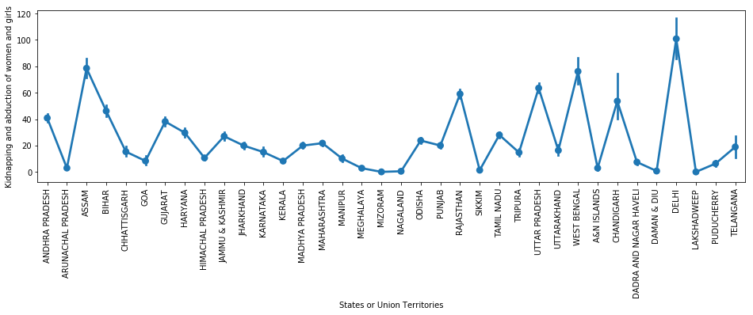

```python
plt.figure(figsize = (16,4))
sb.pointplot(data = india_crimes, x = 'states_or_union_territories', y = 'kidnapping_and_abduction_of_women_and_girls')
plt.xticks(rotation = 90);
plt.ylabel('Kidnapping and abduction of women and girls')
plt.xlabel('States or Union Territories');
```

```python
top5_kidnap_female = aggregate_crimes('states_or_union_territories', 'kidnapping_and_abduction_of_women_and_girls').tail()
clrs = [color_base if (x < max(top5_kidnap_female.kidnapping_and_abduction_of_women_and_girls)) else 'darkred' for x in top5_kidnap_female.kidnapping_and_abduction_of_women_and_girls]
india_crimes.kidnapping_and_abduction_of_women_and_girls.sum()
```

```
346943
```

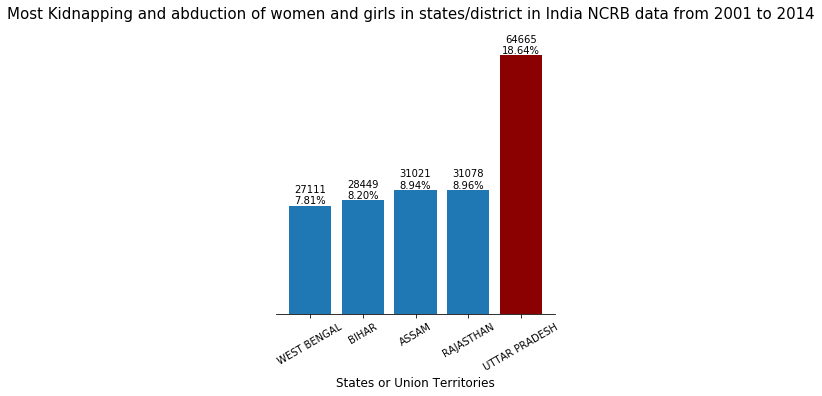

```python
fig = plt.figure(figsize = (5, 5))
# plt.subplot(1,3,1)
# ax1 = sb.barplot(data = top5_kidnap_female, x = 'states_or_union_territories', y = 'kidnapping_and_abduction_of_women_and_girls', palette = clrs)
x = top5_kidnap_female.states_or_union_territories.to_list()
y = top5_kidnap_female.kidnapping_and_abduction_of_women_and_girls.to_list()

ax1 = plt.bar(x, y, color = clrs)
plt.xticks(rotation = 30);
plt.xlabel('States or Union Territories', fontsize=12)
plt.suptitle('Most Kidnapping and abduction of women and girls in states/district in India NCRB data from 2001 to 2014', fontsize = 15);

perc_list_1 = []
num_list_1 = top5_kidnap_female.kidnapping_and_abduction_of_women_and_girls.to_list()

for i in range(0, len(num_list_1)):
    percent = round(100*num_list_1[i]/india_crimes.kidnapping_and_abduction_of_women_and_girls.sum(), 2)
    perc_list_1.append(percent)
# print(perc_list_1)

# Annotation
annotation_perc(ax1, perc_list_1)

# Removing axes
remove_axis()
```

#### Above states taken into the consider. However you can choose different I am sure there different of highest rate of abduction of women and girls

```python
kid_sub_girls = india_crimes[india_crimes.states_or_union_territories.isin(['UTTAR PRADESH', 'RAJASTHAN', 'ASSAM', 'BIHAR', 'WEST BENGAL'])]
```

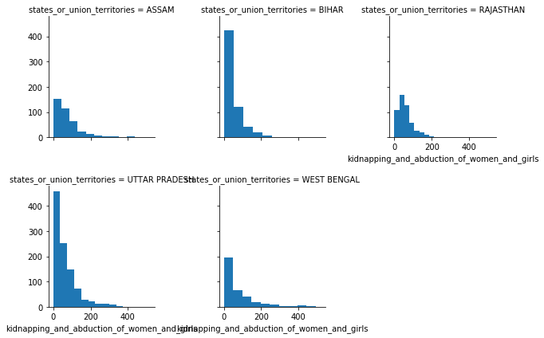

```python
# plt.figure(figsize = (16, 5))
g = sb.FacetGrid(data = kid_sub_girls, col = 'states_or_union_territories', col_wrap = 3, margin_titles = True);
g.map(plt.hist, 'kidnapping_and_abduction_of_women_and_girls');
plt.subplots_adjust(hspace=0.4, wspace=0.6)
```

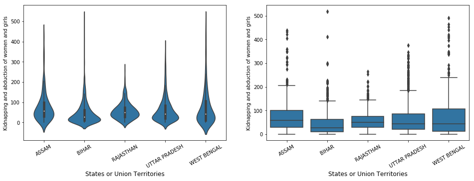

```python
plt.figure(figsize=(16,5))
plt.subplot(1,2,1)
sb.violinplot(data = kid_sub_girls, x = 'states_or_union_territories', y = 'kidnapping_and_abduction_of_women_and_girls', color = base_color)
plt.xticks(rotation = 30);
plt.ylabel('Kidnapping and abduction of women and girls')
plt.xlabel('States or Union Territories', fontsize = 12);

plt.subplot(1,2,2)
sb.boxplot(data = kid_sub_girls, x = 'states_or_union_territories', y = 'kidnapping_and_abduction_of_women_and_girls', color = base_color)
plt.xticks(rotation = 30);
plt.ylabel('Kidnapping and abduction of women and girls')
plt.xlabel('States or Union Territories', fontsize = 12);
```

> Above pointplot shows interesting estimation about kidnapping and abduction of girls and women. `Delhi` has highest mean record i,e it is representing highest rate abduction of state-wise and district-wise. For instance if a state has 10 district, data received from 10 district and then calculate the mean. Thus, `Delhi` has lower district than `Uttar Pradesh`, but higher rate received from the data.

> `Uttar Pradesh`has high crimes of abduction followed by Rajasthan, Assam, Bihar, and West Bengal.

> Violinplot shows the similar result of the above histogram that mode represent between 0 to 100 ranges.

### Mean Kidnapping and Abduction of others:

```python
india_crimes.groupby('states_or_union_territories')['kidnapping_and_abduction_of_others'].sum().sort_values().head()
```

```
states_or_union_territories
LAKSHADWEEP                0
SIKKIM                    21
A&N ISLANDS               27
DAMAN & DIU               27
DADRA AND NAGAR HAVELI    49
Name: kidnapping_and_abduction_of_others, dtype: int64
```

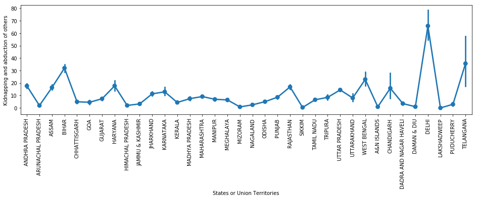

```python
plt.figure(figsize = (16,4))
sb.pointplot(data = india_crimes, x = 'states_or_union_territories', y = 'kidnapping_and_abduction_of_others')
plt.xticks(rotation = 90);
plt.ylabel('Kidnapping and abduction of others')
plt.xlabel('States or Union Territories');
```

```python
top5_kidnap_others = aggregate_crimes('states_or_union_territories', 'kidnapping_and_abduction_of_others').tail()
clrs = [color_base if (x < max(top5_kidnap_others.kidnapping_and_abduction_of_others)) else 'darkred' for x in top5_kidnap_others.kidnapping_and_abduction_of_others]
india_crimes.kidnapping_and_abduction_of_others.sum()
```

```
126118
```

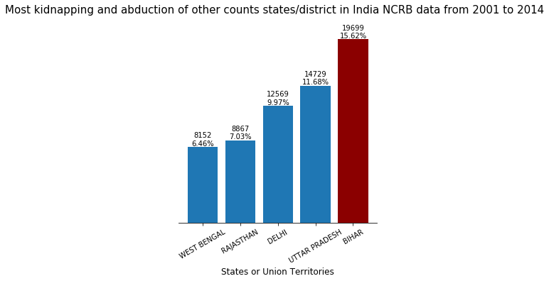

```python
fig = plt.figure(figsize = (5, 5))
# ax1 = sb.barplot(data = top5_kidnap_others, x = 'states_or_union_territories', y = 'kidnapping_and_abduction_of_others', palette = clrs)
x = top5_kidnap_others.states_or_union_territories.to_list()
y = top5_kidnap_others.kidnapping_and_abduction_of_others.to_list()

ax1 = plt.bar(x, y, color = clrs)
plt.xticks(rotation = 30);
plt.xlabel('States or Union Territories', fontsize=12)
plt.suptitle('Most kidnapping and abduction of other counts states/district in India NCRB data from 2001 to 2014', fontsize = 15);

perc_list_1 = []
num_list_1 = top5_kidnap_others.kidnapping_and_abduction_of_others.to_list()

for i in range(0, len(num_list_1)):
    percent = round(100*num_list_1[i]/india_crimes.kidnapping_and_abduction_of_others.sum(), 2)
    perc_list_1.append(percent)
# print(perc_list_1)

# Annotation
annotation_perc(ax1, perc_list_1)

# Removing axes
remove_axis()
```

```python
kid_sub_others = india_crimes[india_crimes.states_or_union_territories.isin(['UTTAR PRADESH', 'RAJASTHAN', 'DELHI', 'BIHAR', 'WEST BENGAL'])]
```

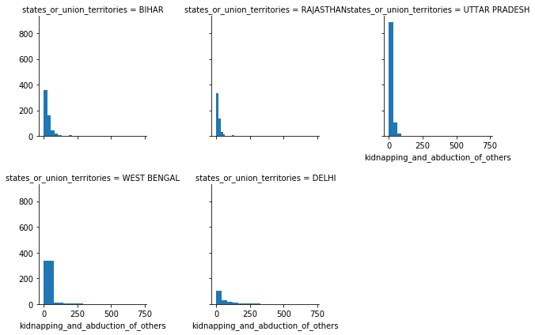

```python
# plt.figure(figsize = (16, 5))
g = sb.FacetGrid(data = kid_sub_others, col = 'states_or_union_territories', col_wrap = 3, margin_titles = True);
g.map(plt.hist, 'kidnapping_and_abduction_of_others');
plt.subplots_adjust(hspace=0.4, wspace=0.6)
```

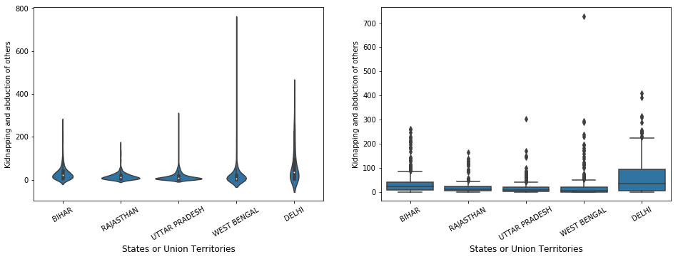

```python
plt.figure(figsize=(16, 5))
plt.subplot(1,2,1)
sb.violinplot(data = kid_sub_others, x = 'states_or_union_territories', y = 'kidnapping_and_abduction_of_others', color = base_color)
plt.xticks(rotation = 30);
plt.ylabel('Kidnapping and abduction of others')
plt.xlabel('States or Union Territories', fontsize = 12);

plt.subplot(1,2,2)
sb.boxplot(data = kid_sub_others, x = 'states_or_union_territories', y = 'kidnapping_and_abduction_of_others', color = base_color)
plt.xticks(rotation = 30);
plt.ylabel('Kidnapping and abduction of others')
plt.xlabel('States or Union Territories', fontsize = 12);
```

https://stackoverflow.com/questions/32067054/remove-rows-of-zeros-from-a-pandas-series

https://stackoverflow.com/questions/54596360/pandas-groupby-multiple-columns-top-n

```python
year_lst = list(set(india_crimes.year))
```

```python
year_list = india_crimes.year.unique().sort_values(ascending = False)
```

```python
def concatenate_loop_dfs(df_temp, df_full, axis=0):
    """
    to avoid retyping the same line of code for every df.
    the parameters should be the temporary df created at each loop and the concatenated DF that will contain all
    values which must first be initialized (outside the loop) as df_name = pd.DataFrame(). """
    if df_full.empty:
    	df_full = df_temp
    else:
    	df_full = pd.concat([df_full, df_temp], axis=axis)
    return df_full
```

```python
df_final = pd.DataFrame()
```

```python
for yr in year_lst:
    # The query function does a search for where
    # the @year means the external variable, in this case the input from loop
    # then you'll have a temporary DF with only the year and sorting and getting top3
    df2 = india_crimes.query("year == @yr")

    df_temp = df2.groupby(['year','states_or_union_territories']).size()
    df_temp = df_temp[df_temp!=0].sort_values(ascending = False).head(3).reset_index(name='count')
    # finally you'll call our function that will keep concating the tmp DFs
    df_final = concatenate_loop_dfs(df_temp, df_final)
```

```python
year_state = df_final.reset_index(drop=True)
year_state = year_state.pivot(index='year', columns='states_or_union_territories', values='count')
# year_state
```

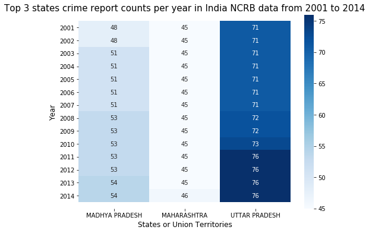

```python
plt.figure(figsize=(8, 6))
ax  = sb.heatmap(year_state, annot=True, cmap="Blues");
bottom, top = ax.get_ylim()
ax.set_ylim(bottom + 0.5, top - 0.5);
plt.xlabel('States or Union Territories', fontsize = 12)
plt.ylabel('Year', fontsize = 12);
plt.title('Top 3 states crime report counts per year in India NCRB data from 2001 to 2014', fontsize = 15);
```

```python
ind_top3_states = india_crimes[india_crimes.states_or_union_territories.isin(['MADHYA PRADESH', 'MAHARASHTRA', 'UTTAR PRADESH'])]
```

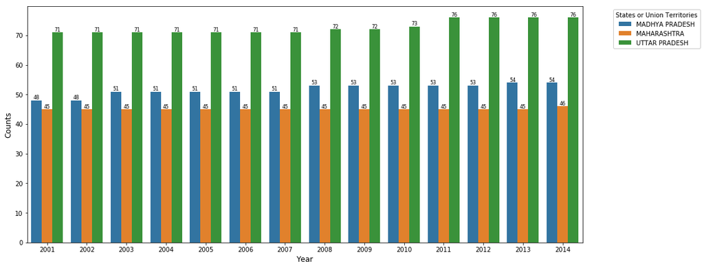

```python
fig = plt.figure(figsize = (16, 7))
ax = sb.countplot(data = ind_top3_states, x = 'year', hue = 'states_or_union_territories')
# plt.xticks(rotation = 15);
ax.legend(framealpha = 1, title = 'States or Union Territories', bbox_to_anchor=(1.05, 1), loc = 'upper left');
plt.xlabel('Year', fontsize = 12)
plt.ylabel('Counts', fontsize = 12)

# Annotate each bar
i=0
for p in ax.patches:
    ax.annotate('{:.0f}'.format(p.get_height()),
                (p.get_x()+p.get_width()/2, p.get_height()),
                ha="center", va="bottom", size=8)
    i+=1
```

> Above graph just dipicting the counts of each year crimes reported of top 3 states in India. `UTTAR PRADESH` followed by `MADHYA PRADESH, MAHARASHTRA`. So there is no doubt the major states has many crimes reported. It is very interesting to see ipc crimes of top 3 states in our the next model of multivariant visulaization.

## Multivariate Exploration

> Create plots of three or more variables to investigate your data even further. Make sure that your investigations are justified, and follow from your work in the previous sections.

```python
india_crimes.columns
```

```
Index(['states_or_union_territories', 'district', 'year', 'murder', 'rape',
       'kidnapping_and_abduction_of_women_and_girls',
       'kidnapping_and_abduction_of_others', 'dacoity', 'robbery', 'thefts',
       'riots', 'criminal_breach_of_trust', 'cheating', 'arson',
       'hurt_or_grievous_hurt', 'dowry_deaths',
       'assault_on_women_with_intent_to_outrage_her_modesty',
       'insult_to_modesty_of_women', 'cruelty_by_husband_or_his_relatives',
       'causing_death_by_negligence', 'total_ipc_crimes'],
      dtype='object')
```

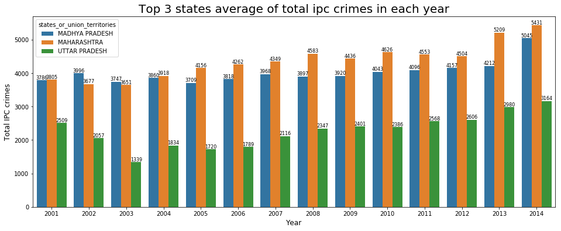

```python
plt.figure(figsize = (16, 6))
ax = sb.barplot(data = ind_top3_states, x = 'year', y = 'total_ipc_crimes', hue = 'states_or_union_territories', ci=None)
# ax.legend(framealpha = 1, title = 'States or Union Territories', bbox_to_anchor=(1.05, 1), loc = 'upper left');
plt.xlabel('Year', fontsize = 12)
plt.ylabel('Total IPC crimes', fontsize = 12)
plt.title('Top 3 states average of total ipc crimes in each year', fontsize = 20)
# Annotate each bar
i=0
for p in ax.patches:
    ax.annotate('{:.0f}'.format(p.get_height()),
                (p.get_x()+p.get_width()/2, p.get_height()),
                ha="center", va="bottom", size=8)
    i+=1
```

```python
india_crimes.head()
```

|  | states_or_union_territories | district | year | murder | rape | kidnapping_and_abduction_of_women_and_girls | kidnapping_and_abduction_of_others | dacoity | robbery | thefts | riots | criminal_breach_of_trust | cheating | arson | hurt_or_grievous_hurt | dowry_deaths | assault_on_women_with_intent_to_outrage_her_modesty | insult_to_modesty_of_women | cruelty_by_husband_or_his_relatives | causing_death_by_negligence | total_ipc_crimes |
| --- | --- | --- | --- | --- | --- | --- | --- | --- | --- | --- | --- | --- | --- | --- | --- | --- | --- | --- | --- | --- | --- |
| 0 | ANDHRA PRADESH | ADILABAD | 2001 | 101.0 | 50.0 | 30.0 | 16.0 | 9.0 | 41.0 | 199.0 | 78.0 | 16.0 | 104.0 | 30.0 | 1131.0 | 16.0 | 149.0 | 34.0 | 175.0 | 181.0 | 4154.0 |
| 1 | ANDHRA PRADESH | ANANTAPUR | 2001 | 151.0 | 23.0 | 30.0 | 23.0 | 8.0 | 16.0 | 366.0 | 168.0 | 11.0 | 65.0 | 69.0 | 1543.0 | 7.0 | 118.0 | 24.0 | 154.0 | 270.0 | 4125.0 |
| 2 | ANDHRA PRADESH | CHITTOOR | 2001 | 101.0 | 27.0 | 34.0 | 25.0 | 4.0 | 14.0 | 723.0 | 156.0 | 33.0 | 209.0 | 38.0 | 2088.0 | 14.0 | 112.0 | 83.0 | 186.0 | 404.0 | 5818.0 |
| 3 | ANDHRA PRADESH | KADAPA | 2001 | 80.0 | 20.0 | 20.0 | 5.0 | 1.0 | 4.0 | 173.0 | 164.0 | 12.0 | 37.0 | 23.0 | 795.0 | 17.0 | 126.0 | 38.0 | 57.0 | 233.0 | 3140.0 |
| 4 | ANDHRA PRADESH | EAST GODAVARI | 2001 | 82.0 | 23.0 | 26.0 | 23.0 | 4.0 | 25.0 | 1021.0 | 70.0 | 50.0 | 220.0 | 41.0 | 1244.0 | 12.0 | 109.0 | 58.0 | 247.0 | 431.0 | 6507.0 |

```python
df_women_atrocity = pd.melt(india_crimes, id_vars = ['year'],
        value_vars = ['rape', 'dowry_deaths', 'assault_on_women_with_intent_to_outrage_her_modesty', 'insult_to_modesty_of_women', 'cruelty_by_husband_or_his_relatives'],
       var_name = 'ipc_crimes_against_women', value_name = 'ipc_crimes_count')
```

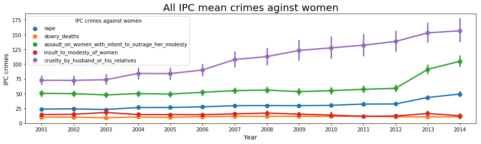

```python
# https://queirozf.com/entries/add-labels-and-text-to-matplotlib-plots-annotation-examples
plt.figure(figsize = (16, 4))
sb.pointplot(data = df_women_atrocity, x = 'year', y='ipc_crimes_count', hue = 'ipc_crimes_against_women');
plt.legend(title = 'IPC crimes against women')
plt.xlabel('Year', fontsize = 12)
plt.ylabel('IPC crimes', fontsize = 12)
plt.title('All IPC mean crimes aginst women', fontsize = 20);
# Annotate each bar
```

### Were there any interesting or surprising interactions between features?

> At the end of your report, make sure that you export the notebook as an html file from the `File > Download as... > HTML` menu. Make sure you keep track of where the exported file goes, so you can put it in the same folder as this notebook for project submission. Also, make sure you remove all of the quote-formatted guide notes like this one before you finish your report!